# Credit_card_fraud_detection

## Credit Card Fraud Detection

In this project you will predict fraudulent credit card transactions with the help of Machine learning models. Please import the following libraries to get started.

```python
import numpy as np
import pandas as pd

import matplotlib.pyplot as plt
%matplotlib inline
import seaborn as sns

from sklearn import metrics
from sklearn import preprocessing;

from sklearn.neighbors import KNeighborsClassifier

import warnings
warnings.filterwarnings("ignore")
warnings.filterwarnings("ignore", category=DeprecationWarning)

from sklearn.model_selection import train_test_split
from sklearn.preprocessing import PowerTransformer

from sklearn.metrics import roc_curve
from sklearn import linear_model
from sklearn.model_selection import GridSearchCV
from sklearn.linear_model import LogisticRegression
from sklearn.model_selection import StratifiedKFold, KFold

from sklearn.metrics import confusion_matrix
from imblearn.metrics import sensitivity_specificity_support
from sklearn.metrics import roc_auc_score
from sklearn.metrics import precision_score
from sklearn.metrics import f1_score
```

```python
from datetime import datetime

now = datetime.now()

current_time = now.strftime("%H:%M:%S")
print("Start Time =", current_time)
```

```
Start Time = 11:30:53
```

## Exploratory data analysis

```python
# from google.colab import drive
# drive.mount('/gdrive')
# %cd /gdrive;
```

```python
# from google.colab import drive
# drive.mount('/drive')
```

```python
from google.colab import drive

drive.mount('/content/drive')
```

```python
# file = r'gdrive/My drive/Colab Notebooks/creditcard.csv'
file = '/content/drive/My Drive/Colab Notebooks/creditcard.csv'
```

```python
ccdf = pd.read_csv(file)
ccdf.head()
```

|  | Time | V1 | V2 | V3 | V4 | V5 | V6 | V7 | V8 | V9 | V10 | V11 | V12 | V13 | V14 | V15 | V16 | V17 | V18 | V19 | V20 | V21 | V22 | V23 | V24 | V25 | V26 | V27 | V28 | … |
| --- | --- | --- | --- | --- | --- | --- | --- | --- | --- | --- | --- | --- | --- | --- | --- | --- | --- | --- | --- | --- | --- | --- | --- | --- | --- | --- | --- | --- | --- | --- |
| 0 | 0.0 | -1.359807 | -0.072781 | 2.536347 | 1.378155 | -0.338321 | 0.462388 | 0.239599 | 0.098698 | 0.363787 | 0.090794 | -0.551600 | -0.617801 | -0.991390 | -0.311169 | 1.468177 | -0.470401 | 0.207971 | 0.025791 | 0.403993 | 0.251412 | -0.018307 | 0.277838 | -0.110474 | 0.066928 | 0.128539 | -0.189115 | 0.133558 | -0.021053 | … |
| 1 | 0.0 | 1.191857 | 0.266151 | 0.166480 | 0.448154 | 0.060018 | -0.082361 | -0.078803 | 0.085102 | -0.255425 | -0.166974 | 1.612727 | 1.065235 | 0.489095 | -0.143772 | 0.635558 | 0.463917 | -0.114805 | -0.183361 | -0.145783 | -0.069083 | -0.225775 | -0.638672 | 0.101288 | -0.339846 | 0.167170 | 0.125895 | -0.008983 | 0.014724 | … |
| 2 | 1.0 | -1.358354 | -1.340163 | 1.773209 | 0.379780 | -0.503198 | 1.800499 | 0.791461 | 0.247676 | -1.514654 | 0.207643 | 0.624501 | 0.066084 | 0.717293 | -0.165946 | 2.345865 | -2.890083 | 1.109969 | -0.121359 | -2.261857 | 0.524980 | 0.247998 | 0.771679 | 0.909412 | -0.689281 | -0.327642 | -0.139097 | -0.055353 | -0.059752 | … |
| 3 | 1.0 | -0.966272 | -0.185226 | 1.792993 | -0.863291 | -0.010309 | 1.247203 | 0.237609 | 0.377436 | -1.387024 | -0.054952 | -0.226487 | 0.178228 | 0.507757 | -0.287924 | -0.631418 | -1.059647 | -0.684093 | 1.965775 | -1.232622 | -0.208038 | -0.108300 | 0.005274 | -0.190321 | -1.175575 | 0.647376 | -0.221929 | 0.062723 | 0.061458 | … |
| 4 | 2.0 | -1.158233 | 0.877737 | 1.548718 | 0.403034 | -0.407193 | 0.095921 | 0.592941 | -0.270533 | 0.817739 | 0.753074 | -0.822843 | 0.538196 | 1.345852 | -1.119670 | 0.175121 | -0.451449 | -0.237033 | -0.038195 | 0.803487 | 0.408542 | -0.009431 | 0.798278 | -0.137458 | 0.141267 | -0.206010 | 0.502292 | 0.219422 | 0.215153 | … |

```python
#observe the different feature type present in the data
ccdf.info()
```

```
<class 'pandas.core.frame.DataFrame'>
RangeIndex: 284807 entries, 0 to 284806
Data columns (total 31 columns):
 #   Column  Non-Null Count   Dtype
---  ------  --------------   -----
 0   Time    284807 non-null  float64
 1   V1      284807 non-null  float64
 2   V2      284807 non-null  float64
 3   V3      284807 non-null  float64
 4   V4      284807 non-null  float64
 5   V5      284807 non-null  float64
 6   V6      284807 non-null  float64
 7   V7      284807 non-null  float64
 8   V8      284807 non-null  float64
 9   V9      284807 non-null  float64
```

[output cut: 23 more lines]

```python
# Shape of dataset
ccdf.shape
```

```
(284807, 31)
```

All feature are numeric with one **int64** with the rest **float64**

The data set contains **284807** observations and 31 **features**

Here we will observe the distribution of our classes

```python
classes=ccdf['Class'].value_counts()
normal_share=classes[0]/ccdf['Class'].count()*100
fraud_share=classes[1]/ccdf['Class'].count()*100
```

```
Total number of Normal Transactions 99.827 %
Total number of Fraud Transactions 0.173 %
```

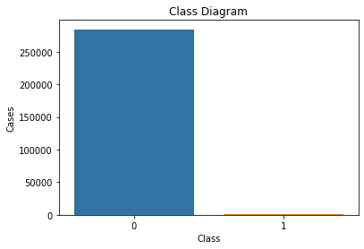

```python
# Create a bar plot for the number and percentage of fraudulent vs non-fraudulent transcations
sns.countplot(x='Class', data=ccdf);
plt.title("Class Diagram")
plt.xlabel("Class")
plt.ylabel("Cases");

print()
print("Total number of Normal Transactions {0}".format(round(normal_share,3)),"%")
print("Total number of Fraud Transactions {0}".format(round(fraud_share,3)),"%")
print()
```

The dataset is **highly imbalanced** with **0.173%** of positive class or 1. So we cannot use any supervised learning algorithm directly because it will overfit based on the ‘Normal’ examples. Let's create a heatmap to see if there is any highly correlated feature.

```python
# Rename some column name or better understanding of the plots
ccdf.rename(columns={'V1':'V01','V2':'V02','V3':'V03','V4':'V04','V5':'V05','V6':'V06','V7':'V07','V8':'V08','V9':'V09'},inplace=True)
cols=ccdf.columns
print(cols)
```

```
Index(['Time', 'V01', 'V02', 'V03', 'V04', 'V05', 'V06', 'V07', 'V08', 'V09',
       'V10', 'V11', 'V12', 'V13', 'V14', 'V15', 'V16', 'V17', 'V18', 'V19',
       'V20', 'V21', 'V22', 'V23', 'V24', 'V25', 'V26', 'V27', 'V28', 'Amount',
       'Class'],
      dtype='object')
```

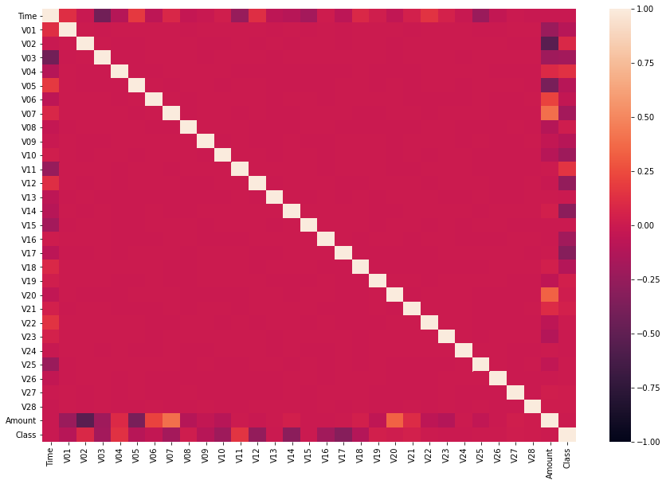

```python
plt.figure(figsize=(15,10))
sns.heatmap(ccdf.corr(), vmin=-1)
plt.show()
```

Overall it seems that we don't have highly correlated features but there is a slighly high negative correlation between Amount and V2, Time and V3 and both time and amount are slightly correlated with other features as well.

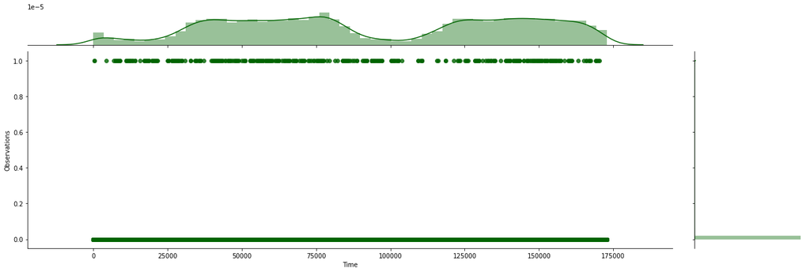

```python
# Create a scatter plot to observe the distribution of classes with time
# We will use joinplot with "reg" to understand the distribution better

s=sns.jointplot(x=ccdf.Time, y=ccdf.Class,data=ccdf,kind='reg', color='darkgreen')
s.fig.set_figheight(6)
s.fig.set_figwidth(20)
plt.xlabel("Time")
plt.ylabel("Observations")
plt.show();
```

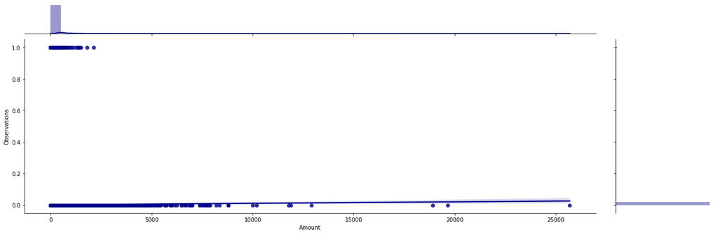

```python
# Create a scatter plot to observe the distribution of classes with Amount
s=sns.jointplot(x=ccdf.Amount, y=ccdf.Class,data=ccdf,kind='reg', color='darkblue')
s.fig.set_figheight(6)
s.fig.set_figwidth(20)
plt.xlabel("Amount")
plt.ylabel("Observations")
plt.show();
```

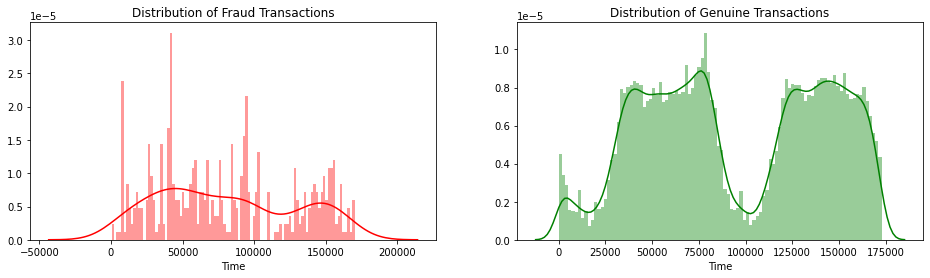

```python
#Distribution of Fraud and Genuine transaction with respect to time
fig, axs = plt.subplots(ncols=2, figsize=(16,4))

sns.distplot(ccdf[(ccdf['Class'] == 1)]['Time'], bins=100, color='red', ax=axs[0])
axs[0].set_title("Distribution of Fraud Transactions")

sns.distplot(ccdf[(ccdf['Class'] == 0)]['Time'], bins=100, color='green', ax=axs[1])
axs[1].set_title("Distribution of Genuine Transactions")

plt.show()
```

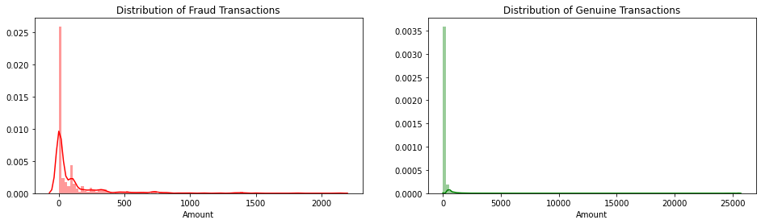

```python
#Distribution of Fraud and Genuine transaction with respect to Amount
fig, axs = plt.subplots(ncols=2, figsize=(16,4))

sns.distplot(ccdf[(ccdf['Class'] == 1)]['Amount'], bins=100, color='red', ax=axs[0])
axs[0].set_title("Distribution of Fraud Transactions")

sns.distplot(ccdf[(ccdf['Class'] == 0)]['Amount'], bins=100, color='green', ax=axs[1])
axs[1].set_title("Distribution of Genuine Transactions")

plt.show()
```

Looking at the above plot, all of the Fraud occured for amount under 4000 USD

```python
# Drop unnecessary columns
#ccdf1=ccdf
#ccdf1.drop('Class',axis=1)
```

```python
# Remove time
ccdf=ccdf.drop('Time',axis=1)
ccdf.columns
```

```
Index(['V01', 'V02', 'V03', 'V04', 'V05', 'V06', 'V07', 'V08', 'V09', 'V10',
       'V11', 'V12', 'V13', 'V14', 'V15', 'V16', 'V17', 'V18', 'V19', 'V20',
       'V21', 'V22', 'V23', 'V24', 'V25', 'V26', 'V27', 'V28', 'Amount',
       'Class'],
      dtype='object')
```

### Splitting the data into train & test data

```python
y= ccdf.pop('Class')
y.head()
```

```
0    0
1    0
2    0
3    0
4    0
Name: Class, dtype: int64
```

```python
X=ccdf
X.head()
```

|  | V01 | V02 | V03 | V04 | V05 | V06 | V07 | V08 | V09 | V10 | V11 | V12 | V13 | V14 | V15 | V16 | V17 | V18 | V19 | V20 | V21 | V22 | V23 | V24 | V25 | V26 | V27 | V28 | Amount |
| --- | --- | --- | --- | --- | --- | --- | --- | --- | --- | --- | --- | --- | --- | --- | --- | --- | --- | --- | --- | --- | --- | --- | --- | --- | --- | --- | --- | --- | --- |
| 0 | -1.359807 | -0.072781 | 2.536347 | 1.378155 | -0.338321 | 0.462388 | 0.239599 | 0.098698 | 0.363787 | 0.090794 | -0.551600 | -0.617801 | -0.991390 | -0.311169 | 1.468177 | -0.470401 | 0.207971 | 0.025791 | 0.403993 | 0.251412 | -0.018307 | 0.277838 | -0.110474 | 0.066928 | 0.128539 | -0.189115 | 0.133558 | -0.021053 | 149.62 |
| 1 | 1.191857 | 0.266151 | 0.166480 | 0.448154 | 0.060018 | -0.082361 | -0.078803 | 0.085102 | -0.255425 | -0.166974 | 1.612727 | 1.065235 | 0.489095 | -0.143772 | 0.635558 | 0.463917 | -0.114805 | -0.183361 | -0.145783 | -0.069083 | -0.225775 | -0.638672 | 0.101288 | -0.339846 | 0.167170 | 0.125895 | -0.008983 | 0.014724 | 2.69 |
| 2 | -1.358354 | -1.340163 | 1.773209 | 0.379780 | -0.503198 | 1.800499 | 0.791461 | 0.247676 | -1.514654 | 0.207643 | 0.624501 | 0.066084 | 0.717293 | -0.165946 | 2.345865 | -2.890083 | 1.109969 | -0.121359 | -2.261857 | 0.524980 | 0.247998 | 0.771679 | 0.909412 | -0.689281 | -0.327642 | -0.139097 | -0.055353 | -0.059752 | 378.66 |
| 3 | -0.966272 | -0.185226 | 1.792993 | -0.863291 | -0.010309 | 1.247203 | 0.237609 | 0.377436 | -1.387024 | -0.054952 | -0.226487 | 0.178228 | 0.507757 | -0.287924 | -0.631418 | -1.059647 | -0.684093 | 1.965775 | -1.232622 | -0.208038 | -0.108300 | 0.005274 | -0.190321 | -1.175575 | 0.647376 | -0.221929 | 0.062723 | 0.061458 | 123.50 |
| 4 | -1.158233 | 0.877737 | 1.548718 | 0.403034 | -0.407193 | 0.095921 | 0.592941 | -0.270533 | 0.817739 | 0.753074 | -0.822843 | 0.538196 | 1.345852 | -1.119670 | 0.175121 | -0.451449 | -0.237033 | -0.038195 | 0.803487 | 0.408542 | -0.009431 | 0.798278 | -0.137458 | 0.141267 | -0.206010 | 0.502292 | 0.219422 | 0.215153 | 69.99 |

```python
from sklearn.model_selection import train_test_split

X_train, X_test, y_train, y_test = train_test_split(X,y,test_size=0.3,random_state=100,shuffle=True)
```

##### Preserve X_test & y_test to evaluate on the test data once you build the model

```python
print(np.sum(y))
print(np.sum(y_train))
print(np.sum(y_test))
print(round(np.sum(y_train)/np.sum(y)*100,1))
print(round(np.sum(y_test)/np.sum(y)*100,1))
```

```
492
350
142
71.1
28.9
```

Looks like the distribution of positive class has been prety well for train and test splits with around 1.1% percent variation

### Plotting the distribution of a variable

```python
# plot the histogram of a variable from the dataset to see the skewness
#fig, axs = plt.subplots(10, 3, squeeze=False,figsize=(20,35))
#for i, ax in enumerate(axs.flatten()):
#    ax.set_title(ccdf1.columns[i])
#    sns.distplot(ccdf1.iloc[:, i], ax=ax,color="blue", fit_kws={"color": "green"})
#    ax.set_xlabel('')
#fig.tight_layout(h_pad=-1.5, w_pad=-1.5)
#plt.show()
```

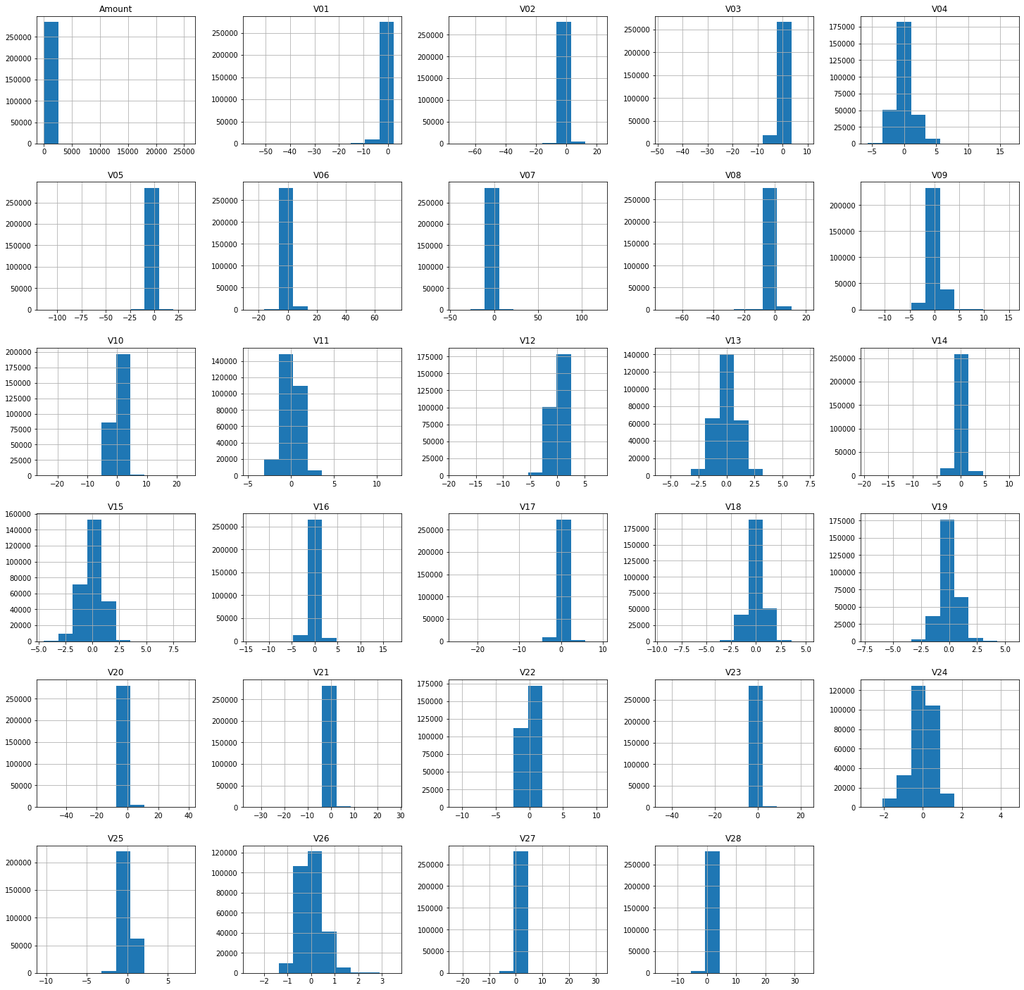

```python
ccdf.hist(figsize = (25,25))
plt.show()
```

We will note stope here. Following we will use PowerTransformer to make the variables more Gausian and remove skewness.

### If there is skewness present in the distribution use:

- **Power Transformer** package present in the **preprocessing library provided by sklearn** to make distribution more gaussian

```python
# - Apply : preprocessing.PowerTransformer(copy=False) to fit & transform the train & test data
from sklearn.preprocessing import PowerTransformer
pt = PowerTransformer(copy=False)

X_train_pt = pd.DataFrame(pt.fit_transform(X_train))
X_test_pt = pd.DataFrame(pt.transform(X_test))
```

```python
column_list = X.columns
X_train_pt.columns = column_list
X_test_pt.columns = column_list
```

```python
X_train_pt.head()
```

|  | V01 | V02 | V03 | V04 | V05 | V06 | V07 | V08 | V09 | V10 | V11 | V12 | V13 | V14 | V15 | V16 | V17 | V18 | V19 | V20 | V21 | V22 | V23 | V24 | V25 | V26 | V27 | V28 | Amount |
| --- | --- | --- | --- | --- | --- | --- | --- | --- | --- | --- | --- | --- | --- | --- | --- | --- | --- | --- | --- | --- | --- | --- | --- | --- | --- | --- | --- | --- | --- |
| 0 | 0.598470 | -0.076635 | 0.414364 | 0.017924 | -0.150960 | 0.345395 | -0.423005 | 0.053042 | 1.152344 | -0.468132 | 2.711653 | -1.044975 | 2.490859 | 1.988839 | 0.192412 | -0.153792 | 0.752506 | -0.799254 | -0.752043 | -0.142787 | -0.217742 | -0.215110 | 0.229615 | -0.518220 | -0.140181 | 1.711153 | -0.180481 | -0.027825 | -1.853467 |
| 1 | 1.445565 | -0.134373 | -0.902690 | 0.208193 | 0.136115 | -0.409005 | 0.073299 | -0.252318 | 0.277355 | 0.257359 | 0.627815 | 1.546125 | 0.529601 | 0.317871 | -0.765034 | 0.165528 | -0.886526 | -0.347125 | 0.754667 | -0.220963 | -0.355324 | -0.881595 | 0.418801 | -0.841362 | -0.510193 | 0.511993 | -0.206056 | -0.220886 | -1.446662 |
| 2 | 0.843049 | -0.987411 | -0.652970 | -1.919788 | 0.423178 | 2.278265 | -1.478071 | 0.853644 | -1.629738 | 1.315947 | -0.265160 | -1.117650 | 0.627704 | -0.502524 | 1.139137 | 0.141712 | -0.192826 | 1.001148 | -0.138704 | -0.090662 | -0.009865 | 0.104342 | -0.203779 | 1.917859 | 0.990486 | 0.014536 | 0.099397 | 0.107899 | 0.706491 |
| 3 | -0.326321 | 0.805913 | -0.366669 | -0.296532 | 0.512231 | -0.805682 | 0.794658 | -0.185940 | 0.130993 | -0.479100 | -0.135555 | 0.007221 | 0.121092 | -1.148253 | -0.307278 | 0.046717 | 0.670351 | -0.599578 | -0.610739 | 0.173877 | -0.457294 | -1.012077 | 0.252022 | 1.861162 | -0.857357 | 0.288656 | 0.854371 | 0.473371 | -1.576187 |
| 4 | 0.566536 | -0.144094 | 0.637616 | 0.445581 | -0.564414 | 0.053504 | -0.482081 | 0.184401 | 0.269297 | 0.107031 | 1.543871 | 0.577842 | -0.847218 | 0.455308 | 1.052225 | 0.485489 | -0.496743 | -0.071757 | -0.563810 | -0.222159 | 0.013937 | -0.092414 | 0.225649 | 0.287704 | -0.037162 | 0.529867 | -0.020486 | 0.051746 | -0.715547 |

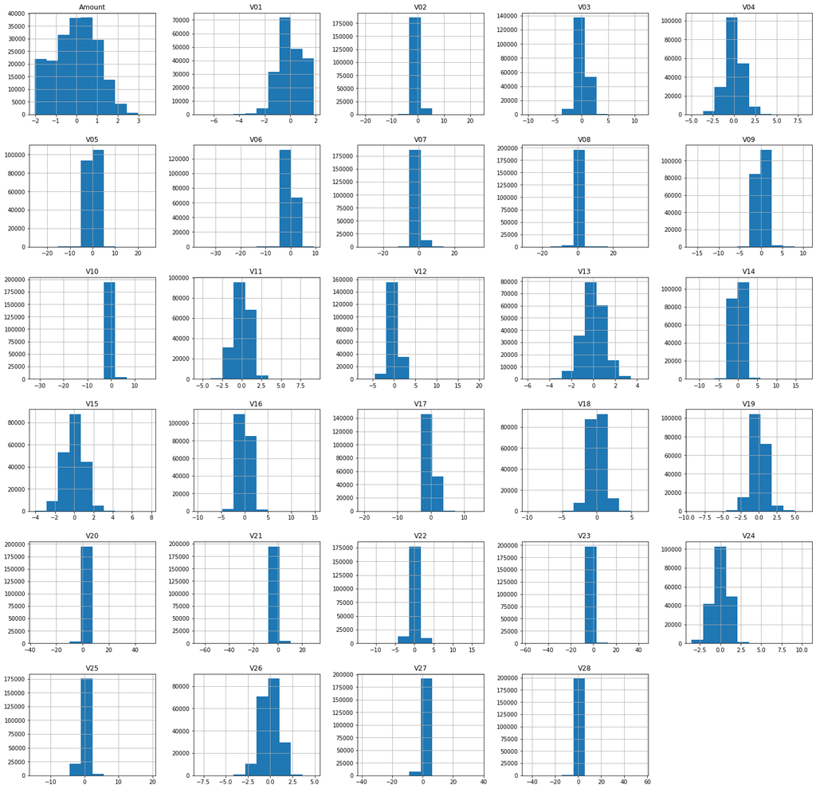

```python
# plotting the Distribution of all variable in X_train after powertransform

X_train_pt.hist(figsize = (25,25))
plt.show()
```

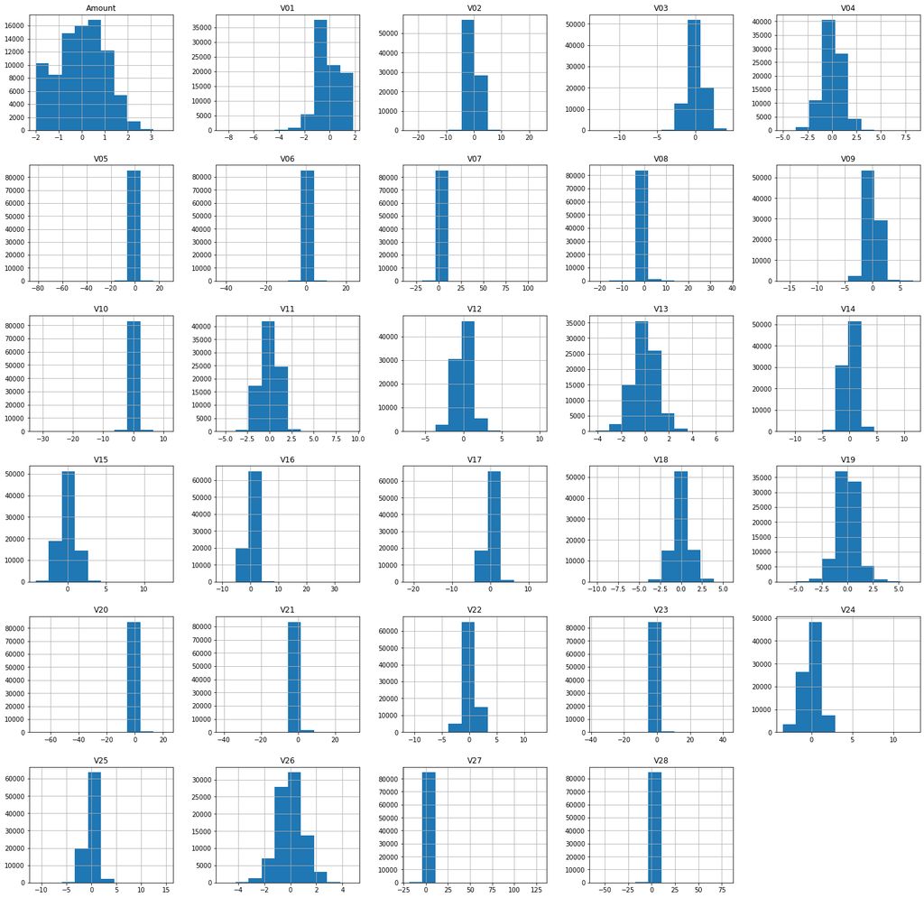

```python
# plotting the Distribution of all variable in X_test after powertransform
X_test_pt.hist(figsize = (25,25))
plt.show()
```

## Model Building

- Build different models on the imbalanced dataset and see the result

```python
# ROC and AUC plot function
from sklearn.metrics import roc_curve
def roc_cure_plot(model):
    logit_roc_auc = roc_auc_score(y_test, model.predict_proba(X_test_pt)[:,1])
    fpr, tpr, thresholds = roc_curve(y_test, model.predict_proba(X_test_pt)[:,1])
    plt.figure(figsize=(4,4))
    plt.plot(fpr, tpr)
    plt.plot([0, 1], [0, 1],'r--')
    plt.xlim([0.0, 1.0])
    plt.ylim([0.0, 1.05])
    plt.xlabel('False Positive Rate')
    plt.ylabel('True Positive Rate')
    plt.title('Receiver operating characteristic(ROC) \n The AUC value is: {:2f}'.format(logit_roc_auc))
    plt.legend(loc="lower right")
    plt.show()
```

```python
##### #Splitting the X_train Power transformed data in Train and Test CV
#scores=[]
#cv = KFold(n_splits=3, random_state=101, shuffle=True)
#cv.split(X_train_pt)
#for train_index, test_index in cv.split(X_train_pt):
  #X_train_cv, X_test_cv = X_train_pt.iloc[train_index], X_train_pt.iloc[test_index]
  #y_train_cv, y_test_cv = y[train_index], y[test_index]
  #model.fit(X_train_cv, y_train_cv)
  #scores.append(model.score(X_test_cv, y_test_cv))

  #print(scores)
```

## 1 - CV Hypertuned - Logistic Model on Imbalanced dataset

```python
# Logistic Regression

#Importing modules

from sklearn import linear_model
from sklearn.model_selection import GridSearchCV
from sklearn.linear_model import LogisticRegression
from sklearn.model_selection import StratifiedKFold, KFold

#setting range of parameters for GridSearch
grid={"C":np.logspace(-3,3,7), "penalty":["l1","l2"]}# l1 lasso l2 ridge

#Number of Folds
kfolds = StratifiedKFold(n_splits = 3, shuffle = True, random_state = 10)


logreg=LogisticRegression()
logreg_cv=GridSearchCV(logreg,grid,cv=kfolds)
logreg_cv.fit(X_train_pt,y_train)

#Print The value of best Hyperparameters
print("tuned hpyerparameters :(best parameters) ",logreg_cv.best_params_)
print("accuracy :",logreg_cv.best_score_)
```

```
tuned hpyerparameters :(best parameters)  {'C': 1.0, 'penalty': 'l2'}
accuracy : 0.9993178306512771
```

```
No handles with labels found to put in legend.
```

```
[[85280    21]
 [   49    93]]
Recall/ Sensitivity/ TPR score: 	0.6549
Specificity/Selectivity/TNR score: 	0.9998
Precision/Positive Predictive score: 0.8157894736842105
F1 Score: 0.7265625000000001
Overall Accuracy Sore: 0.9991807403766253
TRAIN Accuracy: 0.999353
TEST Accuracy: 0.999181
ROC Curve- AUC Score:
```

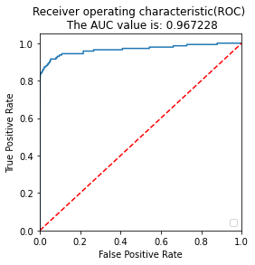

```python
#importing modules

from sklearn.metrics import confusion_matrix
from imblearn.metrics import sensitivity_specificity_support
from sklearn.metrics import roc_auc_score
from sklearn.metrics import precision_score
from sklearn.metrics import f1_score

#Using the best parameters for logistic regression model
model=LogisticRegression( C = 1.0, penalty='l2')

model.fit(X_train_pt,y_train)
#Predicting the hyper tuned model on test set
y_pred = model.predict(X_test_pt)

cm = confusion_matrix(y_test, y_pred)
print(cm)

# Get Common Metrics
sensitivity, specificity, _ = sensitivity_specificity_support(y_test, y_pred, average='binary')
print("Recall/ Sensitivity/ TPR score: \t", round(sensitivity, 4), "\n", "Specificity/Selectivity/TNR score: \t", round(specificity, 4), sep='')
print("Precision/Positive Predictive score: {}".format(precision_score(y_test,y_pred)))
print("F1 Score: {}".format(f1_score(y_test,y_pred)))
print("Overall Accuracy Sore:",metrics.accuracy_score(y_pred,y_test))
print('TRAIN Accuracy: {:2f}'.format(model.score(X_train_pt,y_train)))
print('TEST Accuracy: {:2f}'.format(model.score(X_test,y_test)))
print("ROC Curve- AUC Score: ")
roc_cure_plot(model)
```

## 2- Hypertuned CV- Decision Trees on Imbalanced Data

```python
# Decision Tree

#Import modules
from sklearn.tree import DecisionTreeClassifier
from sklearn.model_selection import RandomizedSearchCV


#Parameters and K fold for decision trees
params = {'max_features': ['auto', 'log2', 'None'],
          'min_samples_split': [2,3,4,5,6,7,8,9,10,11,12,13,14,15],
          'min_samples_leaf':[1,2,3,4,5,6,7,8,9,10,11],
          'random_state':[123]}

kfolds = StratifiedKFold(n_splits = 3, shuffle = True, random_state = 10)

#assigning model to decision tree
model = DecisionTreeClassifier()

#Randomgridsearch
DT = RandomizedSearchCV(model, params, n_jobs =-1, cv =kfolds)

DT.fit(X_train_pt, y_train)

#The best hyper parameters set
print("Best Hyper Parameters:",DT.best_params_)
```

```
Best Hyper Parameters: {'random_state': 123, 'min_samples_split': 13, 'min_samples_leaf': 5, 'max_features': 'auto'}
```

```
Accuracy: 0.9993445923013002

 [[85284    17]
 [   39   103]]

Recall/ Sensitivity/ TPR score: 	0.7254
Specificity/Selectivity/TNR score: 	0.9998
Precision/Positive Predictive score: 0.8583333333333333
F1 Score: 0.7862595419847328
Overall Accuracy Sore: 0.9993445923013002
TRAIN Accuracy: 0.999659
TEST Accuracy: 0.999345
ROC Curve- AUC Score:
```

```
No handles with labels found to put in legend.
```

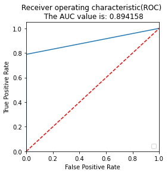

```python
#importing module for evaluation
from sklearn import metrics

#Using the Best Hyper Parameters

model_DT= DecisionTreeClassifier(random_state= 123,
                              min_samples_split= 7,
                              min_samples_leaf= 2,
                              max_features= 'auto')


model_DT.fit(X_train_pt, y_train)

#Prediction on X_test_pt
y_pred_dt=model_DT.predict(X_test_pt)

#evaluation(Accuracy)
print("Accuracy:",metrics.accuracy_score(y_pred_dt,y_test))

# create confusion matrix
cm = confusion_matrix(y_test, y_pred_dt)
print('\n',cm)

# Get Common Metrics
sensitivity, specificity, _ = sensitivity_specificity_support(y_test, y_pred_dt, average='binary')
print('\n',"Recall/ Sensitivity/ TPR score: \t", round(sensitivity, 4), "\n", "Specificity/Selectivity/TNR score: \t", round(specificity, 4), sep='')
print("Precision/Positive Predictive score: {}".format(precision_score(y_test,y_pred_dt)))
print("F1 Score: {}".format(f1_score(y_test,y_pred_dt)))
print("Overall Accuracy Sore:",metrics.accuracy_score(y_pred_dt,y_test))
print('TRAIN Accuracy: {:2f}'.format(model_DT.score(X_train_pt,y_train)))
print('TEST Accuracy: {:2f}'.format(model_DT.score(X_test,y_test)))
print("ROC Curve- AUC Score: ")
roc_cure_plot(model_DT)
```

## 3-XGBOOST for determining extimators

```python
# Finding the best parameters for XG BOost

#Importing the modules
from xgboost import XGBClassifier
from scipy import stats
from sklearn.model_selection import RandomizedSearchCV

#saving XGBoosting in model
model = XGBClassifier()

# Number of Folds
kfolds = StratifiedKFold(n_splits = 3, shuffle = True, random_state = 10)

#Range of Parameters
param_dist = {'n_estimators': stats.randint(10, 200),
              'learning_rate': stats.uniform(0.01, 0.6),
              'subsample': stats.uniform(0.3, 0.9),
              'max_depth': [3, 4, 5, 6, 7],
              'colsample_bytree': stats.uniform(0.5, 0.9),
              'min_child_weight': [1, 2, 3, 4]
             }
#Making models with hyper parameters range
XGB = RandomizedSearchCV(model, param_dist, n_jobs=-1, cv= kfolds)

#Fitting the model on train data
XGB.fit(X_train_pt,y_train)

#The best hyper parameters set
print("Best Hyper Parameters:",XGB.best_params_)
```

```
Best Hyper Parameters: {'colsample_bytree': 0.9506229769035248, 'learning_rate': 0.08795959101003697, 'max_depth': 6, 'min_child_weight': 3, 'n_estimators': 121, 'subsample': 0.480012528304676}
```

```
Accuracy: 0.9995084442259752
[[85292     9]
 [   33   109]]
Recall/ Sensitivity/ TPR score: 	0.7676
Specificity/Selectivity/TNR score: 	0.9999
Precision/Positive Predictive score: 0.923728813559322
F1 Score: 0.8384615384615385
Overall Accuracy Sore: 0.9995084442259752
TRAIN Accuracy: 1.000000
TEST Accuracy: 0.999508
ROC Curve- AUC Score:
```

```
No handles with labels found to put in legend.
```

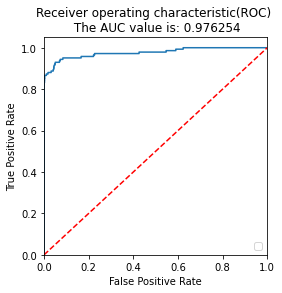

```python
#Using the Best Hyper Parameters derived from the above result
#Setting the best parameters to XGB model

model = XGBClassifier(colsample_bytree = 0.5,
              learning_rate = 0.4,
              max_depth= 5,
              min_child_weight=3,
              n_estimators= 181,
              subsample= 0.9491379369089026)

#Fitting the final model
model.fit(X_train_pt,y_train)

#Prediction
y_pred_xg=model.predict(X_test_pt)

#importing the metrics module
from sklearn import metrics

#evaluation(Accuracy)
print("Accuracy:",metrics.accuracy_score(y_pred_xg,y_test))

# create confusion matrix
cm = confusion_matrix(y_test, y_pred_xg)
print(cm)

# Get Common Metrics
sensitivity, specificity, _ = sensitivity_specificity_support(y_test, y_pred_xg, average='binary')
print("Recall/ Sensitivity/ TPR score: \t", round(sensitivity, 4), "\n", "Specificity/Selectivity/TNR score: \t", round(specificity, 4), sep='')
print("Precision/Positive Predictive score: {}".format(precision_score(y_test,y_pred_xg)))
print("F1 Score: {}".format(f1_score(y_test,y_pred_xg)))
print("Overall Accuracy Sore:",metrics.accuracy_score(y_pred_xg,y_test))
print('TRAIN Accuracy: {:2f}'.format(model.score(X_train_pt,y_train)))
print('TEST Accuracy: {:2f}'.format(model.score(X_test,y_test)))
print("ROC Curve- AUC Score: ")
roc_cure_plot(model)
```

## 4- Hypertuned -Random forest on imbalanced dataset

```python
#Importing Modules
from sklearn.model_selection import RandomizedSearchCV
from sklearn.ensemble import RandomForestClassifier

#making the instance
model=RandomForestClassifier()

#Setting Range of hyper parameters
params = {'criterion':['gini','entropy'],
          'n_estimators':[15,16,17],
          'min_samples_leaf':[3,4,5],
          'min_samples_split':[3,4,5],
          'random_state':[123]
          }

#Number of Folds
kfolds = StratifiedKFold(n_splits = 3, shuffle = True, random_state = 10)

#Making models with hyper parameters sets
RF = RandomizedSearchCV(model, params, n_iter=10, cv =kfolds)

#learning
RF.fit(X_train_pt,y_train)

#The best hyper parameters set
print("Best Hyper Parameters:\n",RF.best_params_)
```

```
Best Hyper Parameters:
 {'random_state': 123, 'n_estimators': 16, 'min_samples_split': 5, 'min_samples_leaf': 3, 'criterion': 'entropy'}
```

```
Accuracy: 0.9993914071369217

 [[85285    16]
 [   36   106]]

Recall/ Sensitivity/ TPR score: 	0.7465
Specificity/Selectivity/TNR score: 	0.9998
Precision/Positive Predictive score: 0.8688524590163934
F1 Score: 0.7862595419847328
Overall Accuracy Sore: 0.9993914071369217
TRAIN Accuracy: 0.999699
TEST Accuracy: 0.999391
ROC Curve- AUC Score:
```

```
No handles with labels found to put in legend.
```

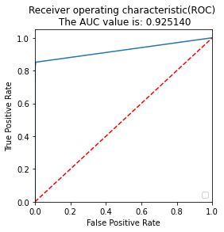

```python
#importing module for evaluation
from sklearn import metrics

#Using the Best Hyper Parameters

model_RF= RandomForestClassifier(random_state= 123, n_estimators=15,
                              min_samples_split= 4,
                              min_samples_leaf= 3,
                              criterion= 'entropy')

#fitting final model on train data
model_RF.fit(X_train_pt,y_train)

#Prediction on X_test_pt
y_pred_rf=model_RF.predict(X_test_pt)

#evaluation(Accuracy)
print("Accuracy:",metrics.accuracy_score(y_pred_rf,y_test))

# create confusion matrix
cm = confusion_matrix(y_test, y_pred_rf)
print('\n',cm)

# Get Common Metrics
sensitivity, specificity, _ = sensitivity_specificity_support(y_test, y_pred_rf, average='binary')
print('\n',"Recall/ Sensitivity/ TPR score: \t", round(sensitivity, 4), "\n", "Specificity/Selectivity/TNR score: \t", round(specificity, 4), sep='')
print("Precision/Positive Predictive score: {}".format(precision_score(y_test,y_pred_rf)))
print("F1 Score: {}".format(f1_score(y_test,y_pred_dt)))
print("Overall Accuracy Sore:",metrics.accuracy_score(y_pred_rf,y_test))
print('TRAIN Accuracy: {:2f}'.format(model_RF.score(X_train_pt,y_train)))
print('TEST Accuracy: {:2f}'.format(model_RF.score(X_test,y_test)))
print("ROC Curve- AUC Score: ")
roc_cure_plot(model_RF)
```

## Hypertuned SVM on imbalanced data

```python
#2-3,SVM
#importing modules

from sklearn import svm
from sklearn.model_selection import RandomizedSearchCV
#making the instance
model=svm.SVC()
#Hyper Parameters Set
params = param_grid = {'C': [0.1,1, 10, 100], 'gamma': [1,0.1,0.01,0.001],'kernel': ['rbf', 'poly', 'sigmoid']}

#Making models with hyper parameters sets
svmm = RandomizedSearchCV(model,params, n_jobs=-1)
#Learning
svmm.fit(X_train_pt,y_train)
#The best hyper parameters set
print("Best Hyper Parameters:\n",svmm.best_params_)
```

Best Hyper Parameters: {'kernel': 'poly', 'gamma': 0.01, 'C': 100}

```python
#importing module for evaluation
from sklearn import metrics
from sklearn import svm

#Using the Best Hyper Parameters

model_svc= svm.SVC(kernel='poly',gamma=0.01,C=100)

#fitting final model on train data
model_svc.fit(X_train_pt,y_train)

#Prediction on X_test_pt
y_pred_svc=model_svc.predict(X_test_pt)

#evaluation(Accuracy)
print("Accuracy:",metrics.accuracy_score(y_pred_svc,y_test))

# create confusion matrix
cm = confusion_matrix(y_test, y_pred_svc)
print('\n',cm)

# Get Common Metrics
sensitivity, specificity, _ = sensitivity_specificity_support(y_test, y_pred_svc, average='binary')
print('\n',"Recall/ Sensitivity/ TPR score: \t", round(sensitivity, 4), "\n", "Specificity/Selectivity/TNR score: \t", round(specificity, 4), sep='')
print("Precision/Positive Predictive score: {}".format(precision_score(y_test,y_pred_svc)))
print("F1 Score: {}".format(f1_score(y_test,y_pred_svc)))
print("Overall Accuracy Sore:",metrics.accuracy_score(y_pred_svc,y_test))
print('TRAIN Accuracy: {:2f}'.format(model_RF.score(X_train_pt,y_train)))
print('TEST Accuracy: {:2f}'.format(model_RF.score(X_test,y_test)))
print("ROC Curve- AUC Score: ")
roc_cure_plot(model_RF)
```

[output not shown]

## Hypertuned CV - Knn on Imbalanced Data

## !!!! KNN WAS TAKING TOO MUCH SO IGNORED THIS ALGORITHM!!!!!

```python
# from sklearn.neighbors import KNeighborsClassifier
# k_range = range(1, 11)
# score1=[]
# score2=[]
# for k in k_range:
#     knn=KNeighborsClassifier(n_neighbors=k,n_jobs=-1)
#     knn.fit(X_train_pt,y_train)
#     score1.append(knn.score(X_train_pt,y_train))
#     score2.append(knn.score(X_test_pt,y_test))

# %matplotlib inline
# plt.plot(k_range,score1,label= 'Accuracy on training set')
# plt.plot(k_range,score2,label= 'Accuracy on testing set')
# plt.xlabel('Value of K in KNN')
# plt.ylabel('Accuracy')
# plt.legend()
```

```python
#Setup knn classifier with k neighbors =
# knn = KNeighborsClassifier(n_neighbors=7)
# knn.fit(X_train_pt,y_train)
```

```python
#let us get the predictions using the classifier we had fit above
# y_pred = knn.predict(X_test)
```

```python
# #With Hyper Parameters Tuning

# #making the instance
# model_knn = KNeighborsClassifier(n_neighbors=3,leaf_size=3,p=2,)

# #Learning
# model_knn.fit(X_train_pt,y_train)

# #Prediction
# y_pred_knn=model_knn.predict(X_test_pt)

# #evaluation(Accuracy)
# print("Accuracy:",metrics.accuracy_score(y_pred_knn,y_test))
# roc_cure_plot(model_knn)

# #evaluation(Confusion Metrix)
# print("Confusion Metrix:\n",metrics.confusion_matrix(y_pred_knn,y_test))

# # Get Common Metrics
# sensitivity, specificity, _ = sensitivity_specificity_support(y_test, y_pred_knn, average='binary')
# print('\n',"Recall/ Sensitivity/ TPR score: \t", round(sensitivity, 4), "\n", "Specificity/Selectivity/TNR score: \t", round(specificity, 4), sep='')
# print("Precision/Positive Predictive score: {}".format(precision_score(y_test,y_pred_knn)))
# print("F1 Score: {}".format(f1_score(y_test,y_pred_knn)))
# print("Overall Accuracy Sore:",metrics.accuracy_score(y_pred_knn,y_test))
# print('TRAIN Accuracy: {:2f}'.format(model_knn.score(X_train_pt,y_train)))
# print('TEST Accuracy: {:2f}'.format(model_knn.score(X_test,y_test)))
# print("ROC Curve- AUC Score: ")
# roc_cure_plot(model_knn)
```

### Logistic Regression:

1. Overall Accuracy: 0.99918
2. Positive Predictive: 0.815789
3. F1 Score: 0.726562
4. AUC Score: 0.96722

### Decision Tree:

1. Overall Accuracy: 0.999346
2. Positive Predictive: 0.858333
3. F1 Score: 0.786259
4. AUC Score: 0.894158

### XG Boost:

1. Overall Accuracy: **0. 999508**
2. Positive Predictive: **0.923729**
3. F1 Score: **0.838461**
4. AUC Score: **0.976254**

#### As can bee seen above, XG Boost has the best evaluation metrics for Overall Accuracy, Positive Predictive Value, F1 Score, and AUC Score

#### Now we will procceed with the result of XG Boost

#### Proceed with the model which shows the best result

- Apply the best hyperparameter on the model
- Predict on the test dataset

```
Accuracy: 0.9995084442259752
[[85292     9]
 [   33   109]]
Recall/ Sensitivity/ TPR score: 	0.7676
Specificity/Selectivity/TNR score: 	0.9999
Precision/Positive Predictive score: 0.923728813559322
F1 Score: 0.8384615384615385
Overall Accuracy Sore: 0.9995084442259752
TRAIN Accuracy: 1.000000
TEST Accuracy: 0.999508
ROC Curve- AUC Score:
```

```
No handles with labels found to put in legend.
```

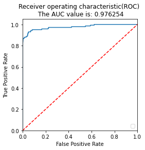

```
Important Features
```

```python
#clf =  #initialise the model with optimum hyperparameters
clf=XGBClassifier(colsample_bytree = 0.5,
              learning_rate = 0.4,
              max_depth= 5,
              min_child_weight=3,
              n_estimators= 181,
              subsample= 0.9491379369089026)
#clf.fit(X_train, y_train)
clf.fit(X_train_pt,y_train)

#Prediction
y_pred_xg=clf.predict(X_test_pt)

#importing the metrics module
from sklearn import metrics

#evaluation(Accuracy)
print("Accuracy:",metrics.accuracy_score(y_pred_xg,y_test))

# create confusion matrix
cm = confusion_matrix(y_test, y_pred_xg)
print(cm)

# Get Common Metrics
sensitivity, specificity, _ = sensitivity_specificity_support(y_test, y_pred_xg, average='binary')
print("Recall/ Sensitivity/ TPR score: \t", round(sensitivity, 4), "\n", "Specificity/Selectivity/TNR score: \t", round(specificity, 4), sep='')
print("Precision/Positive Predictive score: {}".format(precision_score(y_test,y_pred_xg)))
print("F1 Score: {}".format(f1_score(y_test,y_pred_xg)))
print("Overall Accuracy Sore:",metrics.accuracy_score(y_pred_xg,y_test))
print('TRAIN Accuracy: {:2f}'.format(clf.score(X_train_pt,y_train)))
print('TEST Accuracy: {:2f}'.format(clf.score(X_test,y_test)))
print("ROC Curve- AUC Score: ")
roc_cure_plot(clf)

#print --> #print the evaluation score on the X_test by choosing the best evaluation metric
print("Important Features")
```

```python
# clf.best_estimator_.feature_importances_
clf.feature_importances_
```

```
array([0.02252374, 0.02138875, 0.01824348, 0.040271  , 0.02104419,
       0.01479261, 0.04620537, 0.01999644, 0.01362527, 0.06586805,
       0.1512412 , 0.09459648, 0.00933911, 0.08322714, 0.01205188,
       0.0585397 , 0.12494048, 0.01643148, 0.0146497 , 0.01273131,
       0.01706995, 0.01332982, 0.01172323, 0.01280108, 0.01270014,
       0.02575505, 0.01451045, 0.01808703, 0.01231576], dtype=float32)
```

## Print the important features of the best model to understand the dataset

- This will not give much explanation on the already transformed dataset
- But it will help us in understanding if the dataset is not PCA transformed

```
Top var = 11
2nd Top var = 17
3rd Top var = 12
```

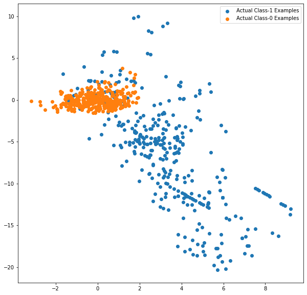

```python
#Proceed with the model which shows the best result

clf=XGBClassifier(colsample_bytree = 0.5,
              learning_rate = 0.4,
              max_depth= 5,
              min_child_weight=3,
              n_estimators= 181,
              subsample= 0.9491379369089026)
#Fitting the final model
clf.fit(X_train_pt,y_train)
var_imp = []
for i in clf.feature_importances_:
    var_imp.append(i)
print('Top var =', var_imp.index(np.sort(clf.feature_importances_)[-1])+1)
print('2nd Top var =', var_imp.index(np.sort(clf.feature_importances_)[-2])+1)
print('3rd Top var =', var_imp.index(np.sort(clf.feature_importances_)[-3])+1)

# Variable on Index-16 and Index-13 seems to be the top 2 variables
top_var_index = var_imp.index(np.sort(clf.feature_importances_)[-1])
second_top_var_index = var_imp.index(np.sort(clf.feature_importances_)[-2])

X_train_1 = X_train.to_numpy()[np.where(y_train==1.0)]
X_train_0 = X_train.to_numpy()[np.where(y_train==0.0)]

np.random.shuffle(X_train_0)

import matplotlib.pyplot as plt
%matplotlib inline
plt.rcParams['figure.figsize'] = [10, 10]

plt.scatter(X_train_1[:, top_var_index], X_train_1[:, second_top_var_index], label='Actual Class-1 Examples')
plt.scatter(X_train_0[:X_train_1.shape[0], top_var_index], X_train_0[:X_train_1.shape[0], second_top_var_index],
            label='Actual Class-0 Examples')
plt.legend()
```

## Model building with balancing Classes

##### Perform class balancing with :

- Random Oversampling
- SMOTE
- ADASYN

## Model Building

- Build different models on the balanced dataset and see the result

### Random Oversampling

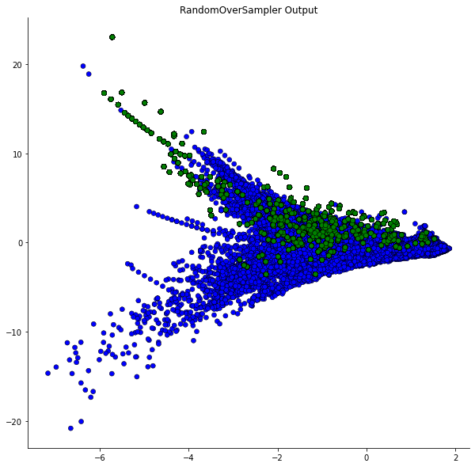

```python
from imblearn import over_sampling #- import the packages
from imblearn.over_sampling import RandomOverSampler

#perform cross validation & then balance classes on X_train_cv & y_train_cv using Random Oversampling
ros = RandomOverSampler(random_state=0)
ros.fit(X_train_pt, y_train)
X_resampled, y_resampled = ros.fit_resample(X_train_pt, y_train)
colors = ['b' if v == 0 else 'g' if v == 1 else 'r' for v in y_resampled]
plt.scatter(X_resampled[:, 0], X_resampled[:, 1], c=colors, linewidth=0.5, edgecolor='black')
sns.despine()
plt.title("RandomOverSampler Output")
pass
```

## Hypertuned Logistic regression on Random Oversampled Data

```python
# Logistic Regression

#Importing modules

from sklearn import linear_model
from sklearn.model_selection import GridSearchCV
from sklearn.linear_model import LogisticRegression
from sklearn.model_selection import StratifiedKFold, KFold

#setting range of parameters for GridSearch
grid={"C":np.logspace(-3,3,7), "penalty":["l1","l2"]}# l1 lasso l2 ridge

#Number of Folds
kfolds = StratifiedKFold(n_splits = 3, shuffle = True, random_state = 10)


logreg=LogisticRegression()
logreg_cv=GridSearchCV(logreg,grid,cv=kfolds)
logreg_cv.fit(X_resampled,y_resampled)

#Print The value of best Hyperparameters
print("tuned hpyerparameters :(best parameters) ",logreg_cv.best_params_)
print("accuracy :",logreg_cv.best_score_)
```

```
tuned hpyerparameters :(best parameters)  {'C': 0.001, 'penalty': 'l2'}
accuracy : 0.9521591445827932
```

```
No handles with labels found to put in legend.
```

```
[[83525  1776]
 [   19   123]]
Recall/ Sensitivity/ TPR score: 	0.8662
Specificity/Selectivity/TNR score: 	0.9792
Precision/Positive Predictive score: 0.06477093206951026
F1 Score: 0.12052915237628613
Overall Accuracy Sore: 0.978991842514893
TRAIN Accuracy: 0.979635
TEST Accuracy: 0.978992
ROC Curve- AUC Score:
```

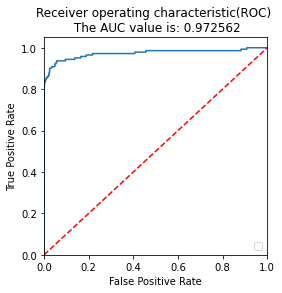

```python
#importing modules

from sklearn.metrics import confusion_matrix
from imblearn.metrics import sensitivity_specificity_support
from sklearn.metrics import roc_auc_score
from sklearn.metrics import precision_score
from sklearn.metrics import f1_score

#Using the best parameters for logistic regression model
model=LogisticRegression( C = 0.001, penalty='l2')

model.fit(X_resampled,y_resampled)

#Predicting the hyper tuned model on test set
y_pred = model.predict(X_test_pt)

cm = confusion_matrix(y_test, y_pred)
print(cm)

# Get Common Metrics
sensitivity, specificity, _ = sensitivity_specificity_support(y_test, y_pred, average='binary')
print("Recall/ Sensitivity/ TPR score: \t", round(sensitivity, 4), "\n", "Specificity/Selectivity/TNR score: \t", round(specificity, 4), sep='')
print("Precision/Positive Predictive score: {}".format(precision_score(y_test,y_pred)))
print("F1 Score: {}".format(f1_score(y_test,y_pred)))
print("Overall Accuracy Sore:",metrics.accuracy_score(y_pred,y_test))
print('TRAIN Accuracy: {:2f}'.format(model.score(X_train_pt,y_train)))
print('TEST Accuracy: {:2f}'.format(model.score(X_test,y_test)))
print("ROC Curve- AUC Score: ")
roc_cure_plot(model)
```

## Hypertuned Random Forest on Random Oversampled Data

```python
#Importing Modules
from sklearn.model_selection import RandomizedSearchCV
from sklearn.ensemble import RandomForestClassifier

#making the instance
model=RandomForestClassifier()

#Setting Range of hyper parameters
params = {'criterion':['gini','entropy'],
          'n_estimators':[15,16,17],
          'min_samples_leaf':[3,4,5],
          'min_samples_split':[3,4,5],
          'random_state':[123]
          }

#Number of Folds
kfolds = StratifiedKFold(n_splits = 3, shuffle = True, random_state = 10)

#Making models with hyper parameters sets
RF = RandomizedSearchCV(model, params, n_iter=10, cv =kfolds)

#learning
RF.fit(X_resampled,y_resampled)

#The best hyper parameters set
print("Best Hyper Parameters:\n",RF.best_params_)
```

```
Best Hyper Parameters:
 {'random_state': 123, 'n_estimators': 16, 'min_samples_split': 4, 'min_samples_leaf': 4, 'criterion': 'entropy'}
```

```
Accuracy: 0.9993797034280163

 [[85280    21]
 [   32   110]]

Recall/ Sensitivity/ TPR score: 	0.7746
Specificity/Selectivity/TNR score: 	0.9998
Precision/Positive Predictive score: 0.8396946564885496
F1 Score: 0.8058608058608059
Overall Accuracy Sore: 0.9993797034280163
TRAIN Accuracy: 0.999920
TEST Accuracy: 0.999380
ROC Curve- AUC Score:
```

```
No handles with labels found to put in legend.
```

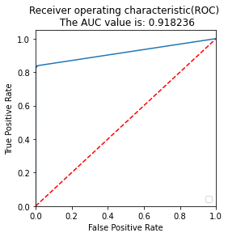

```python
#importing module for evaluation
from sklearn import metrics

#Using the Best Hyper Parameters

model_RF= RandomForestClassifier(random_state= 123, n_estimators=16,
                              min_samples_split= 3,
                              min_samples_leaf= 3,
                              criterion= 'gini')

model_RF.fit(X_resampled,y_resampled)

#Prediction on X_test_pt
y_pred_rf=model_RF.predict(X_test_pt)

#evaluation(Accuracy)
print("Accuracy:",metrics.accuracy_score(y_pred_rf,y_test))

# create confusion matrix
cm = confusion_matrix(y_test, y_pred_rf)
print('\n',cm)

# Get Common Metrics
sensitivity, specificity, _ = sensitivity_specificity_support(y_test, y_pred_rf, average='binary')
print('\n',"Recall/ Sensitivity/ TPR score: \t", round(sensitivity, 4), "\n", "Specificity/Selectivity/TNR score: \t", round(specificity, 4), sep='')
print("Precision/Positive Predictive score: {}".format(precision_score(y_test,y_pred_rf)))
print("F1 Score: {}".format(f1_score(y_test,y_pred_rf)))
print("Overall Accuracy Sore:",metrics.accuracy_score(y_pred_rf,y_test))
print('TRAIN Accuracy: {:2f}'.format(model_RF.score(X_train_pt,y_train)))
print('TEST Accuracy: {:2f}'.format(model_RF.score(X_test,y_test)))
print("ROC Curve- AUC Score: ")
roc_cure_plot(model_RF)
```

## Hypertune Decision Tree On Random Oversample Data

```python
# Decision Tree

#Import modules
from sklearn.tree import DecisionTreeClassifier
from sklearn.model_selection import RandomizedSearchCV


#Parameters and K fold for decision trees
params = {'max_features': ['auto', 'log2', 'None'],
          'min_samples_split': [2,3,4,5,6,7,8,9,10],
          'min_samples_leaf':[4,5,6,7,8,9,10],
          'random_state':[123]}

kfolds = StratifiedKFold(n_splits = 3, shuffle = True, random_state = 100)

#assigning model to decision tree
model = DecisionTreeClassifier()

#Randomgridsearch
DT = RandomizedSearchCV(model, params, n_jobs =-1, cv =kfolds)

DT.fit(X_resampled, y_resampled)

#The best hyper parameters set
print("Best Hyper Parameters:",DT.best_params_)
```

```
Best Hyper Parameters: {'random_state': 123, 'min_samples_split': 5, 'min_samples_leaf': 7, 'max_features': 'auto'}
```

```
Accuracy: 0.9990519995786665

 [[85261    40]
 [   41   101]]

Recall/ Sensitivity/ TPR score: 	0.7113
Specificity/Selectivity/TNR score: 	0.9995
Precision/Positive Predictive score: 0.7163120567375887
F1 Score: 0.7137809187279152
Overall Accuracy Sore: 0.9990519995786665
TRAIN Accuracy: 0.999814
TEST Accuracy: 0.999052
ROC Curve- AUC Score:
```

```
No handles with labels found to put in legend.
```

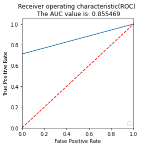

```python
#importing module for evaluation
from sklearn import metrics

#Using the Best Hyper Parameters

model_DT= DecisionTreeClassifier(random_state= 123,
                              min_samples_split= 7,
                              min_samples_leaf= 5,
                              max_features= 'log2')

model_DT.fit(X_resampled,y_resampled)

#Prediction on X_test_pt
y_pred_dt=model_DT.predict(X_test_pt)

#evaluation(Accuracy)
print("Accuracy:",metrics.accuracy_score(y_pred_dt,y_test))

# create confusion matrix
cm = confusion_matrix(y_test, y_pred_dt)
print('\n',cm)

# Get Common Metrics
sensitivity, specificity, _ = sensitivity_specificity_support(y_test, y_pred_dt, average='binary')
print('\n',"Recall/ Sensitivity/ TPR score: \t", round(sensitivity, 4), "\n", "Specificity/Selectivity/TNR score: \t", round(specificity, 4), sep='')
print("Precision/Positive Predictive score: {}".format(precision_score(y_test,y_pred_dt)))
print("F1 Score: {}".format(f1_score(y_test,y_pred_dt)))
print("Overall Accuracy Sore:",metrics.accuracy_score(y_pred_dt,y_test))
print('TRAIN Accuracy: {:2f}'.format(model_DT.score(X_train_pt,y_train)))
print('TEST Accuracy: {:2f}'.format(model_DT.score(X_test,y_test)))
print("ROC Curve- AUC Score: ")
roc_cure_plot(model_DT)
```

## XGboost ON Random Oversampling balanced data

```python
from sklearn import metrics
def xg_roc_auc_curve(target_test,test_preds):
    fpr, tpr, threshold = metrics.roc_curve(target_test, test_preds)
    roc_auc = metrics.auc(fpr, tpr)
    plt.figure(figsize=(6,5))
    plt.plot(fpr, tpr, 'b')
    plt.title('Receiver operating characteristic(ROC) \n The AUC value is: {:2f}'.format(roc_auc))
    plt.plot([0, 1], [0, 1],'r--')
    plt.ylabel('True Positive Rate')
    plt.xlabel('False Positive Rate')
```

```python
# Finding the best parameters for XG BOost

#Importing the modules
from xgboost import XGBClassifier
from scipy import stats
from sklearn.model_selection import RandomizedSearchCV

#saving XGBoosting in model
model = XGBClassifier()

# Number of Folds
kfolds = StratifiedKFold(n_splits = 3, shuffle = True, random_state = 10)

#Range of Parameters
param_dist = {'n_estimators': stats.randint(10, 200),
              'learning_rate': stats.uniform(0.01, 0.6),
              'subsample': stats.uniform(0.3, 0.9),
              'max_depth': [3, 4, 5, 6, 7],
              'colsample_bytree': stats.uniform(0.5, 0.9),
              'min_child_weight': [1, 2, 3, 4]
             }
#Making models with hyper parameters range
XGB = RandomizedSearchCV(model, param_dist, n_jobs=-1, cv= kfolds)

#Fitting the model on train data
XGB.fit(X_resampled,y_resampled)

#The best hyper parameters set
print("Best Hyper Parameters:",XGB.best_params_)
```

```
Best Hyper Parameters: {'colsample_bytree': 0.6237738537181579, 'learning_rate': 0.29792341898661123, 'max_depth': 4, 'min_child_weight': 4, 'n_estimators': 112, 'subsample': 0.7609548091184054}
```

```
Accuracy: 0.9995435553526912
[[85288    13]
 [   26   116]]
Recall/ Sensitivity/ TPR score: 	0.8169
Specificity/Selectivity/TNR score: 	0.9998
Precision/Positive Predictive score: 0.8992248062015504
F1 Score: 0.8560885608856088
Overall Accuracy Sore: 0.9995435553526912
TRAIN Accuracy: 0.979635
TEST Accuracy: 0.978992
ROC- AUC Score:
```

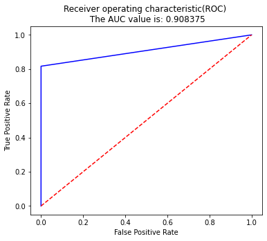

```python
#Using the Best Hyper Parameters derived from the above result
#Setting the best parameters to XGB model

model = XGBClassifier(colsample_bytree = 0.9,
              learning_rate = 0.5,
              max_depth= 7,
              min_child_weight=3,
              n_estimators= 138,
              subsample= 0.8)

model.fit(X_resampled, y_resampled)

#Prediction

y_pred_xg=model.predict(X_test_pt.to_numpy())
#importing the metrics module
from sklearn import metrics
#evaluation(Accuracy)
print("Accuracy:",metrics.accuracy_score(y_pred_xg,y_test))

# create confusion matrix
cm = confusion_matrix(y_test, y_pred_xg)
print(cm)

# Get Common Metrics
sensitivity, specificity, _ = sensitivity_specificity_support(y_test, y_pred_xg, average='binary')
print("Recall/ Sensitivity/ TPR score: \t", round(sensitivity, 4), "\n", "Specificity/Selectivity/TNR score: \t", round(specificity, 4), sep='')
print("Precision/Positive Predictive score: {}".format(precision_score(y_test,y_pred_xg)))
print("F1 Score: {}".format(f1_score(y_test,y_pred_xg)))
print("Overall Accuracy Sore:",metrics.accuracy_score(y_pred_xg,y_test))
print('TRAIN Accuracy: {:2f}'.format(logreg_cv.score(X_train_pt,y_train)))
print('TEST Accuracy: {:2f}'.format(logreg_cv.score(X_test,y_test)))
print("ROC- AUC Score: ")
xg_roc_auc_curve(y_test,y_pred_xg)
```

## Evaluation Metrics Result on Random Oversampling:

### Logistic Regression:

1. Overall Accuracy: 0.97899
2. Positive Predictive: 0.0647
3. F1 Score: 0.1205
4. AUC Score: 0.972562

### Random Forest:

1. Overall Accuracy: 0.99937
2. Positive Predictive: 0.83969
3. F1 Score: 0.80586
4. AUC Score: 0.918236

### XG Boost:

1. Overall Accuracy: **0.99954**
2. Positive Predictive: **0.8992**
3. F1 Score: **0.85609**
4. AUC Score: 0.90837

### Overall the performance of XG boost is better than other models in Overall accuracy, Postive Predictive, and F1 Score

## Print the class distribution after applying SMOTE

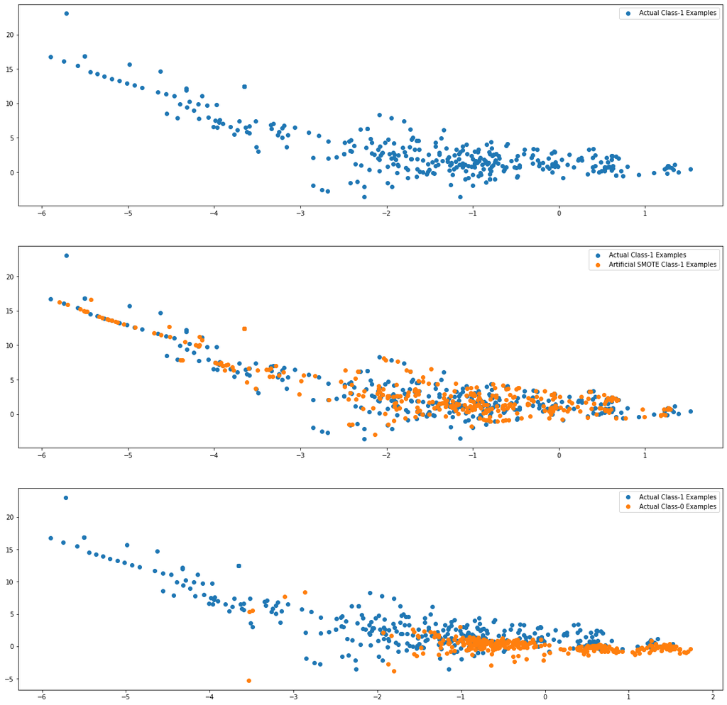

```python
import warnings
warnings.filterwarnings("ignore")

from imblearn import over_sampling


sm = over_sampling.SMOTE(random_state=0)
X_train_smote, y_train_smote = sm.fit_resample(X_train_pt, y_train)
# Artificial minority samples and corresponding minority labels from SMOTE are appended
# below X_train and y_train respectively
# So to exclusively get the artificial minority samples from SMOTE, we do
X_train_smote_1 = X_train_smote[X_train_pt.shape[0]:]

X_train_1 = X_train_pt.to_numpy()[np.where(y_train==1.0)]
X_train_0 = X_train_pt.to_numpy()[np.where(y_train==0.0)]


plt.rcParams['figure.figsize'] = [20, 20]
fig = plt.figure()

plt.subplot(3, 1, 1)
plt.scatter(X_train_1[:, 0], X_train_1[:, 1], label='Actual Class-1 Examples')
plt.legend()

plt.subplot(3, 1, 2)
plt.scatter(X_train_1[:, 0], X_train_1[:, 1], label='Actual Class-1 Examples')
plt.scatter(X_train_smote_1[:X_train_1.shape[0], 0], X_train_smote_1[:X_train_1.shape[0], 1],
            label='Artificial SMOTE Class-1 Examples')
plt.legend()

plt.subplot(3, 1, 3)
plt.scatter(X_train_1[:, 0], X_train_1[:, 1], label='Actual Class-1 Examples')
plt.scatter(X_train_0[:X_train_1.shape[0], 0], X_train_0[:X_train_1.shape[0], 1], label='Actual Class-0 Examples')
plt.legend()
```

## Hypertuned Logistic regression on SMOTE Data

```python
# Logistic Regression

#Importing modules

from sklearn import linear_model
from sklearn.model_selection import GridSearchCV
from sklearn.linear_model import LogisticRegression
from sklearn.model_selection import StratifiedKFold, KFold

#setting range of parameters for GridSearch
grid={"C":np.logspace(-3,3,7), "penalty":["l1","l2"]}# l1 lasso l2 ridge

#Number of Folds
kfolds = StratifiedKFold(n_splits = 3, shuffle = True, random_state = 10)


logreg=LogisticRegression()
logreg_cv=GridSearchCV(logreg,grid,cv=kfolds)
logreg_cv.fit(X_train_smote,y_train_smote)

#Print The value of best Hyperparameters
print("tuned hpyerparameters :(best parameters) ",logreg_cv.best_params_)
print("accuracy :",logreg_cv.best_score_)
```

```
tuned hpyerparameters :(best parameters)  {'C': 0.01, 'penalty': 'l2'}
accuracy : 0.9504758459203876
```

```
No handles with labels found to put in legend.
```

```
[[83197  2104]
 [   16   126]]
Recall/ Sensitivity/ TPR score: 	0.8873
Specificity/Selectivity/TNR score: 	0.9753
Precision/Positive Predictive score: 0.05650224215246637
F1 Score: 0.10623946037099495
Overall Accuracy Sore: 0.9751881371206536
TRAIN Accuracy: 0.976174
TEST Accuracy: 0.975188
ROC Curve- AUC Score:
```

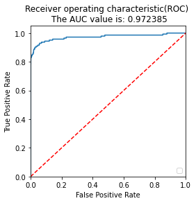

```python
#importing modules

from sklearn.metrics import confusion_matrix
from imblearn.metrics import sensitivity_specificity_support
from sklearn.metrics import roc_auc_score
from sklearn.metrics import precision_score
from sklearn.metrics import f1_score

#Using the best parameters for logistic regression model
model=LogisticRegression( C = 0.01, penalty='l2')

model.fit(X_train_smote,y_train_smote)

#Predicting the hyper tuned model on test set
y_pred = model.predict(X_test_pt)

cm = confusion_matrix(y_test, y_pred)
print(cm)

# Get Common Metrics
sensitivity, specificity, _ = sensitivity_specificity_support(y_test, y_pred, average='binary')
print("Recall/ Sensitivity/ TPR score: \t", round(sensitivity, 4), "\n", "Specificity/Selectivity/TNR score: \t", round(specificity, 4), sep='')
print("Precision/Positive Predictive score: {}".format(precision_score(y_test,y_pred)))
print("F1 Score: {}".format(f1_score(y_test,y_pred)))
print("Overall Accuracy Sore:",metrics.accuracy_score(y_pred,y_test))
print('TRAIN Accuracy: {:2f}'.format(model.score(X_train_pt,y_train)))
print('TEST Accuracy: {:2f}'.format(model.score(X_test_pt,y_test)))
print("ROC Curve- AUC Score: ")
roc_cure_plot(model)
```

## Hypertuned Random Forest on SMOTE Data

```python
#Importing Modules
from sklearn.model_selection import RandomizedSearchCV
from sklearn.ensemble import RandomForestClassifier

#making the instance
model=RandomForestClassifier()

#Setting Range of hyper parameters
params = {'criterion':['gini','entropy'],
          'n_estimators':[15,16,17],
          'min_samples_leaf':[3,4,5],
          'min_samples_split':[3,4,5],
          'random_state':[123]
          }

#Number of Folds
kfolds = StratifiedKFold(n_splits = 3, shuffle = True, random_state = 10)

#Making models with hyper parameters sets
RF = RandomizedSearchCV(model, params, n_iter=10, cv =kfolds)

#learning
RF.fit(X_train_smote,y_train_smote)

#The best hyper parameters set
print("Best Hyper Parameters:\n",RF.best_params_)
```

```
Best Hyper Parameters:
 {'random_state': 123, 'n_estimators': 16, 'min_samples_split': 5, 'min_samples_leaf': 3, 'criterion': 'gini'}
```

```
Accuracy: 0.9992509626300574

 [[85266    35]
 [   29   113]]

Recall/ Sensitivity/ TPR score: 	0.7958
Specificity/Selectivity/TNR score: 	0.9996
Precision/Positive Predictive score: 0.7635135135135135
F1 Score: 0.7793103448275862
Overall Accuracy Sore: 0.9992509626300574
TRAIN Accuracy: 0.999885
TEST Accuracy: 0.999251
ROC Curve- AUC Score:
```

```
No handles with labels found to put in legend.
```

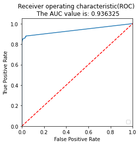

```python
#importing module for evaluation
from sklearn import metrics

#Using the Best Hyper Parameters

model_RF= RandomForestClassifier(random_state= 123, n_estimators=17,
                              min_samples_split= 4,
                              min_samples_leaf= 3,
                              criterion= 'entropy')

model_RF.fit(X_train_smote,y_train_smote)

#Prediction on X_test_pt
y_pred_rf=model_RF.predict(X_test_pt)

#evaluation(Accuracy)
print("Accuracy:",metrics.accuracy_score(y_pred_rf,y_test))

# create confusion matrix
cm = confusion_matrix(y_test, y_pred_rf)
print('\n',cm)

# Get Common Metrics
sensitivity, specificity, _ = sensitivity_specificity_support(y_test, y_pred_rf, average='binary')
print('\n',"Recall/ Sensitivity/ TPR score: \t", round(sensitivity, 4), "\n", "Specificity/Selectivity/TNR score: \t", round(specificity, 4), sep='')
print("Precision/Positive Predictive score: {}".format(precision_score(y_test,y_pred_rf)))
print("F1 Score: {}".format(f1_score(y_test,y_pred_rf)))
print("Overall Accuracy Sore:",metrics.accuracy_score(y_pred_rf,y_test))
print('TRAIN Accuracy: {:2f}'.format(model_RF.score(X_train_pt,y_train)))
print('TEST Accuracy: {:2f}'.format(model_RF.score(X_test_pt,y_test)))
print("ROC Curve- AUC Score: ")
roc_cure_plot(model_RF)
```

## Hypertune Decision Tree On SMOTE Data

```python
# Decision Tree

#Import modules
from sklearn.tree import DecisionTreeClassifier
from sklearn.model_selection import RandomizedSearchCV


#Parameters and K fold for decision trees
params = {'max_features': ['auto', 'log2', 'None'],
          'min_samples_split': [2,3,4,5,6,7,8,9,10],
          'min_samples_leaf':[4,5,6,7,8,9,10],
          'random_state':[123]}

kfolds = StratifiedKFold(n_splits = 3, shuffle = True, random_state = 10)

#assigning model to decision tree
model = DecisionTreeClassifier()

#Randomgridsearch
DT = RandomizedSearchCV(model, params, n_jobs =-1, cv =kfolds)

DT.fit(X_train_smote, y_train_smote)

#The best hyper parameters set
print("Best Hyper Parameters:",DT.best_params_)
```

```
Best Hyper Parameters: {'random_state': 123, 'min_samples_split': 10, 'min_samples_leaf': 5, 'max_features': 'log2'}
```

```
Accuracy: 0.9967814800510282

 [[85056   245]
 [   30   112]]

Recall/ Sensitivity/ TPR score: 	0.7887
Specificity/Selectivity/TNR score: 	0.9971
Precision/Positive Predictive score: 0.3137254901960784
F1 Score: 0.44889779559118226
Overall Accuracy Sore: 0.9967814800510282
TRAIN Accuracy: 0.998806
TEST Accuracy: 0.996781
ROC Curve- AUC Score:
```

```
No handles with labels found to put in legend.
```

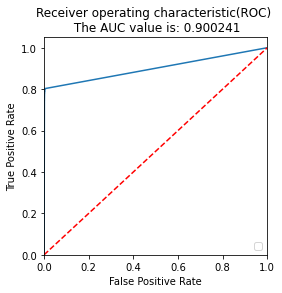

```python
#importing module for evaluation
from sklearn import metrics

#Using the Best Hyper Parameters

model_DT= DecisionTreeClassifier(random_state= 123,
                              min_samples_split= 3,
                              min_samples_leaf= 5,
                              max_features= 'auto')

model_DT.fit(X_train_smote,y_train_smote)

#Prediction on X_test_pt
y_pred_dt=model_DT.predict(X_test_pt)

#evaluation(Accuracy)
print("Accuracy:",metrics.accuracy_score(y_pred_dt,y_test))

# create confusion matrix
cm = confusion_matrix(y_test, y_pred_dt)
print('\n',cm)

# Get Common Metrics
sensitivity, specificity, _ = sensitivity_specificity_support(y_test, y_pred_dt, average='binary')
print('\n',"Recall/ Sensitivity/ TPR score: \t", round(sensitivity, 4), "\n", "Specificity/Selectivity/TNR score: \t", round(specificity, 4), sep='')
print("Precision/Positive Predictive score: {}".format(precision_score(y_test,y_pred_dt)))
print("F1 Score: {}".format(f1_score(y_test,y_pred_dt)))
print("Overall Accuracy Sore:",metrics.accuracy_score(y_pred_dt,y_test))
print('TRAIN Accuracy: {:2f}'.format(model_DT.score(X_train_pt,y_train)))
print('TEST Accuracy: {:2f}'.format(model_DT.score(X_test_pt,y_test)))
print("ROC Curve- AUC Score: ")
roc_cure_plot(model_DT)
```

## XGboost on SMOTE data

```python
# Finding the best parameters for XG BOost

#Importing the modules
from xgboost import XGBClassifier
from scipy import stats
from sklearn.model_selection import RandomizedSearchCV

#saving XGBoosting in model
model = XGBClassifier()

# Number of Folds
kfolds = StratifiedKFold(n_splits = 3, shuffle = True, random_state = 100)

#Range of Parameters
param_dist = {'n_estimators': stats.randint(10, 200),
              'learning_rate': stats.uniform(0.01, 0.6),
              'subsample': stats.uniform(0.3, 0.9),
              'max_depth': [3, 4, 5, 6, 7],
              'colsample_bytree': stats.uniform(0.5, 0.9),
              'min_child_weight': [1, 2, 3, 4]
             }
#Making models with hyper parameters range
XGB = RandomizedSearchCV(model, param_dist, n_jobs=-1, cv= kfolds)

#Fitting the model on train data
XGB.fit(X_train_smote,y_train_smote)

#The best hyper parameters set
print("Best Hyper Parameters:",XGB.best_params_)
```

```
Best Hyper Parameters: {'colsample_bytree': 0.9614319106602289, 'learning_rate': 0.40009708771746133, 'max_depth': 6, 'min_child_weight': 2, 'n_estimators': 53, 'subsample': 0.927903715319649}
```

```
Accuracy: 0.9991105181231933
[[85252    49]
 [   27   115]]
Recall/ Sensitivity/ TPR score: 	0.8099
Specificity/Selectivity/TNR score: 	0.9994
Precision/Positive Predictive score: 0.7012195121951219
F1 Score: 0.7516339869281046
Overall Accuracy Sore: 0.9991105181231933
TRAIN Accuracy: 0.999995
TEST Accuracy: 0.999111
ROC- AUC Score:
```

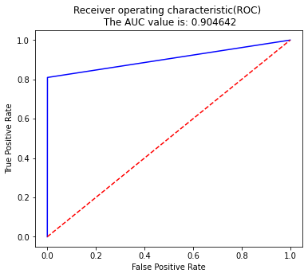

```python
#Using the Best Hyper Parameters derived from the above result
#Setting the best parameters to XGB model
from xgboost import XGBClassifier
from sklearn.metrics import confusion_matrix
from imblearn.metrics import sensitivity_specificity_support
from sklearn.metrics import roc_auc_score
from sklearn.metrics import precision_score
from sklearn.metrics import f1_score

model = XGBClassifier(colsample_bytree = 0.5157839301386529,
              learning_rate = 0.2986209256145927,
              max_depth= 7,
              min_child_weight=3,
              n_estimators= 133,
              subsample= 0.8227089119114395)


model.fit(X_train_smote, y_train_smote)

#Prediction

y_pred_xg=model.predict(X_test_pt.to_numpy())
#importing the metrics module
from sklearn import metrics
#evaluation(Accuracy)
print("Accuracy:",metrics.accuracy_score(y_pred_xg,y_test))

# create confusion matrix
cm = confusion_matrix(y_test, y_pred_xg)
print(cm)

# Get Common Metrics
sensitivity, specificity, _ = sensitivity_specificity_support(y_test, y_pred_xg, average='binary')
print("Recall/ Sensitivity/ TPR score: \t", round(sensitivity, 4), "\n", "Specificity/Selectivity/TNR score: \t", round(specificity, 4), sep='')
print("Precision/Positive Predictive score: {}".format(precision_score(y_test,y_pred_xg)))
print("F1 Score: {}".format(f1_score(y_test,y_pred_xg)))
print("Overall Accuracy Sore:",metrics.accuracy_score(y_pred_xg,y_test))
print('TRAIN Accuracy: {:2f}'.format(model.score(X_train_smote,y_train_smote)))
print('TEST Accuracy: {:2f}'.format(model.score(X_test_pt.to_numpy(),y_test)))
print("ROC- AUC Score: ")
xg_roc_auc_curve(y_test,y_pred_xg)
```

## Evaluation Metrics using SMOTE

### Random Forest:

1. Overall Accuracy: **0.99925**
2. Positive Predictive: **0.76351**
3. F1 Score: **0.77931**
4. AUC Score: **0.93632**

### Decision Tree:

1. Overall Accuracy: 0.99678
2. Positive Predictive: 0.31372
3. F1 Score: 0.44889
4. AUC Score: 0.90024

### XG Boost:

1. Overall Accuracy: 0.99911
2. Positive Predictive: 0.70121
3. F1 Score: 0.75163
4. AUC Score: 0.90464

### Print the class distribution after applying ADASYN

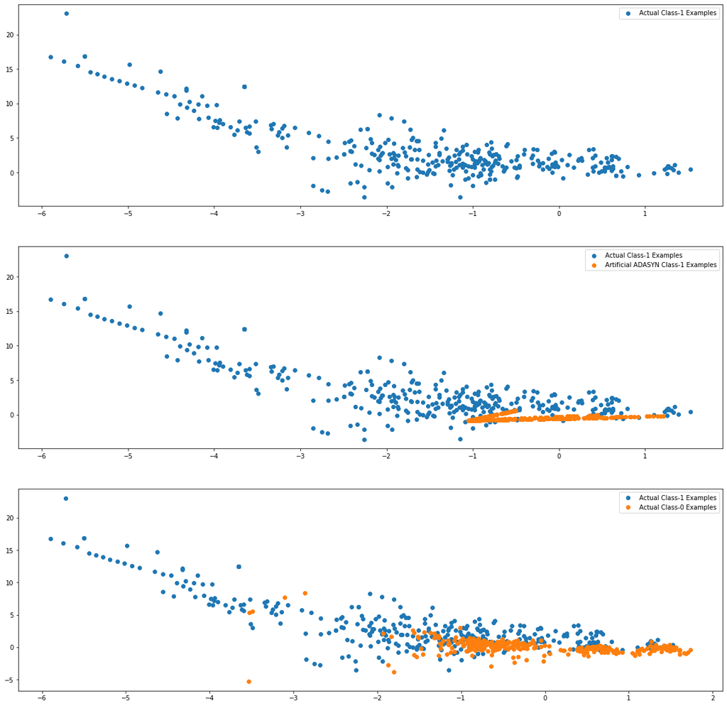

```python
import warnings
warnings.filterwarnings("ignore")

from imblearn import over_sampling

ada = over_sampling.ADASYN(random_state=0)
X_train_adasyn, y_train_adasyn = ada.fit_resample(X_train, y_train)
# Artificial minority samples and corresponding minority labels from ADASYN are appended
# below X_train and y_train respectively
# So to exclusively get the artificial minority samples from ADASYN, we do
X_train_adasyn_1 = X_train_adasyn[X_train.shape[0]:]

X_train_1 = X_train.to_numpy()[np.where(y_train==1.0)]
X_train_0 = X_train.to_numpy()[np.where(y_train==0.0)]



import matplotlib.pyplot as plt
%matplotlib inline
plt.rcParams['figure.figsize'] = [20, 20]
fig = plt.figure()

plt.subplot(3, 1, 1)
plt.scatter(X_train_1[:, 0], X_train_1[:, 1], label='Actual Class-1 Examples')
plt.legend()

plt.subplot(3, 1, 2)
plt.scatter(X_train_1[:, 0], X_train_1[:, 1], label='Actual Class-1 Examples')
plt.scatter(X_train_adasyn_1[:X_train_1.shape[0], 0], X_train_adasyn_1[:X_train_1.shape[0], 1],
            label='Artificial ADASYN Class-1 Examples')
plt.legend()

plt.subplot(3, 1, 3)
plt.scatter(X_train_1[:, 0], X_train_1[:, 1], label='Actual Class-1 Examples')
plt.scatter(X_train_0[:X_train_1.shape[0], 0], X_train_0[:X_train_1.shape[0], 1], label='Actual Class-0 Examples')
plt.legend()
```

```python
#perform cross validation & then balance classes on X_train_cv & y_train_cv using ADASYN

#perform hyperparameter tuning

#print the evaluation result by choosing a evaluation metric

#print the optimum value of hyperparameters
```

## Hypertuned Logistic regression on ADASYN Oversampled Data

```python
# Logistic Regression

#Importing modules

from sklearn import linear_model
from sklearn.model_selection import GridSearchCV
from sklearn.linear_model import LogisticRegression
from sklearn.model_selection import StratifiedKFold, KFold

#setting range of parameters for GridSearch
grid={"C":np.logspace(-3,3,7), "penalty":["l1","l2"]}# l1 lasso l2 ridge

#Number of Folds
kfolds = StratifiedKFold(n_splits = 3, shuffle = True, random_state = 10)


logreg=LogisticRegression()
logreg_cv=GridSearchCV(logreg,grid,cv=kfolds)
logreg_cv.fit(X_train_adasyn,y_train_adasyn)

#Print The value of best Hyperparameters
print("tuned hpyerparameters :(best parameters) ",logreg_cv.best_params_)
print("accuracy :",logreg_cv.best_score_)
```

```
tuned hpyerparameters :(best parameters)  {'C': 100.0, 'penalty': 'l2'}
accuracy : 0.889148226805507
```

```
No handles with labels found to put in legend.
```

```
[[77715  7586]
 [    8   134]]
Recall/ Sensitivity/ TPR score: 	0.9437
Specificity/Selectivity/TNR score: 	0.9111
Precision/Positive Predictive score: 0.017357512953367876
F1 Score: 0.034088018315950146
Overall Accuracy Sore: 0.9111220345727561
TRAIN Accuracy: 0.912963
TEST Accuracy: 0.911122
ROC Curve- AUC Score:
```

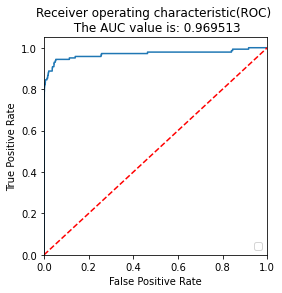

```python
#importing modules

from sklearn.metrics import confusion_matrix
from imblearn.metrics import sensitivity_specificity_support
from sklearn.metrics import roc_auc_score
from sklearn.metrics import precision_score
from sklearn.metrics import f1_score

#Using the best parameters for logistic regression model
model=LogisticRegression( C = 100.0, penalty='l2')

model.fit(X_train_adasyn,y_train_adasyn)

#Predicting the hyper tuned model on test set
y_pred = model.predict(X_test_pt)

cm = confusion_matrix(y_test, y_pred)
print(cm)

# Get Common Metrics
sensitivity, specificity, _ = sensitivity_specificity_support(y_test, y_pred, average='binary')
print("Recall/ Sensitivity/ TPR score: \t", round(sensitivity, 4), "\n", "Specificity/Selectivity/TNR score: \t", round(specificity, 4), sep='')
print("Precision/Positive Predictive score: {}".format(precision_score(y_test,y_pred)))
print("F1 Score: {}".format(f1_score(y_test,y_pred)))
print("Overall Accuracy Sore:",metrics.accuracy_score(y_pred,y_test))
print('TRAIN Accuracy: {:2f}'.format(model.score(X_train_pt,y_train)))
print('TEST Accuracy: {:2f}'.format(model.score(X_test,y_test)))
print("ROC Curve- AUC Score: ")
roc_cure_plot(model)
```

## Hypertuned Random Forest on ADASYNC Oversampled Data

```python
#Importing Modules
from sklearn.model_selection import RandomizedSearchCV
from sklearn.ensemble import RandomForestClassifier

#making the instance
model=RandomForestClassifier()

#Setting Range of hyper parameters
params = {'criterion':['gini','entropy'],
          'n_estimators':[15,16,17],
          'min_samples_leaf':[3,4,5],
          'min_samples_split':[3,4,5],
          'random_state':[123]
          }

#Number of Folds
kfolds = StratifiedKFold(n_splits = 3, shuffle = True, random_state = 10)

#Making models with hyper parameters sets
RF = RandomizedSearchCV(model, params, n_iter=10, cv =kfolds)

#learning
RF.fit(X_train_adasyn,y_train_adasyn)

#The best hyper parameters set
print("Best Hyper Parameters:\n",RF.best_params_)
```

```
Best Hyper Parameters:
 {'random_state': 123, 'n_estimators': 17, 'min_samples_split': 5, 'min_samples_leaf': 4, 'criterion': 'entropy'}
```

Best Hyper Parameters: {'random_state': 123, 'n_estimators': 15, 'min_samples_split': 4, 'min_samples_leaf': 4, 'criterion': 'entropy'}

```
Accuracy: 0.9992626663389628

 [[85266    35]
 [   28   114]]

Recall/ Sensitivity/ TPR score: 	0.8028
Specificity/Selectivity/TNR score: 	0.9996
Precision/Positive Predictive score: 0.7651006711409396
F1 Score: 0.7835051546391754
Overall Accuracy Sore: 0.9992626663389628
TRAIN Accuracy: 0.999855
TEST Accuracy: 0.999263
ROC Curve- AUC Score:
```

```
No handles with labels found to put in legend.
```

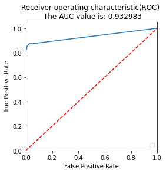

```python
#importing module for evaluation
from sklearn import metrics

#Using the Best Hyper Parameters

model_RF= RandomForestClassifier(random_state= 123, n_estimators=15,
                              min_samples_split= 4,
                              min_samples_leaf= 4,
                              criterion= 'entropy')

model_RF.fit(X_train_adasyn,y_train_adasyn)

#Prediction on X_test_pt
y_pred_rf=model_RF.predict(X_test_pt)

#evaluation(Accuracy)
print("Accuracy:",metrics.accuracy_score(y_pred_rf,y_test))

# create confusion matrix
cm = confusion_matrix(y_test, y_pred_rf)
print('\n',cm)

# Get Common Metrics
sensitivity, specificity, _ = sensitivity_specificity_support(y_test, y_pred_rf, average='binary')
print('\n',"Recall/ Sensitivity/ TPR score: \t", round(sensitivity, 4), "\n", "Specificity/Selectivity/TNR score: \t", round(specificity, 4), sep='')
print("Precision/Positive Predictive score: {}".format(precision_score(y_test,y_pred_rf)))
print("F1 Score: {}".format(f1_score(y_test,y_pred_rf)))
print("Overall Accuracy Sore:",metrics.accuracy_score(y_pred_rf,y_test))
print('TRAIN Accuracy: {:2f}'.format(model_RF.score(X_train_pt,y_train)))
print('TEST Accuracy: {:2f}'.format(model_RF.score(X_test,y_test)))
print("ROC Curve- AUC Score: ")
roc_cure_plot(model_RF)
```

## Hypertune Decision Tree On ADASYNC Oversample Data

```python
# Decision Tree

#Import modules
from sklearn.tree import DecisionTreeClassifier
from sklearn.model_selection import RandomizedSearchCV


#Parameters and K fold for decision trees
params = {'max_features': ['auto', 'log2', 'None'],
          'min_samples_split': [2,3,4,5,6,7,8,9,10],
          'min_samples_leaf':[4,5,6,7,8,9,10],
          'random_state':[123]}

kfolds = StratifiedKFold(n_splits = 3, shuffle = True, random_state = 10)

#assigning model to decision tree
model = DecisionTreeClassifier()

#Randomgridsearch
DT = RandomizedSearchCV(model, params, n_jobs =-1, cv =kfolds)

DT.fit(X_train_adasyn,y_train_adasyn)

#The best hyper parameters set
print("Best Hyper Parameters:",DT.best_params_)
```

```
Best Hyper Parameters: {'random_state': 123, 'min_samples_split': 5, 'min_samples_leaf': 4, 'max_features': 'auto'}
```

```
Accuracy: 0.9974251840408226

 [[85118   183]
 [   37   105]]

Recall/ Sensitivity/ TPR score: 	0.7394
Specificity/Selectivity/TNR score: 	0.9979
Precision/Positive Predictive score: 0.3645833333333333
F1 Score: 0.4883720930232558
Overall Accuracy Sore: 0.9974251840408226
TRAIN Accuracy: 0.999333
TEST Accuracy: 0.997425
ROC Curve- AUC Score:
```

```
No handles with labels found to put in legend.
```

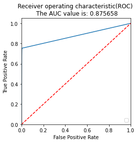

```python
#importing module for evaluation
from sklearn import metrics

#Using the Best Hyper Parameters

model_DT= DecisionTreeClassifier(random_state= 123,
                              min_samples_split= 2,
                              min_samples_leaf= 4,
                              max_features= 'auto')

model_DT.fit(X_train_adasyn,y_train_adasyn)

#Prediction on X_test_pt
y_pred_dt=model_DT.predict(X_test_pt)

#evaluation(Accuracy)
print("Accuracy:",metrics.accuracy_score(y_pred_dt,y_test))

# create confusion matrix
cm = confusion_matrix(y_test, y_pred_dt)
print('\n',cm)

# Get Common Metrics
sensitivity, specificity, _ = sensitivity_specificity_support(y_test, y_pred_dt, average='binary')
print('\n',"Recall/ Sensitivity/ TPR score: \t", round(sensitivity, 4), "\n", "Specificity/Selectivity/TNR score: \t", round(specificity, 4), sep='')
print("Precision/Positive Predictive score: {}".format(precision_score(y_test,y_pred_dt)))
print("F1 Score: {}".format(f1_score(y_test,y_pred_dt)))
print("Overall Accuracy Sore:",metrics.accuracy_score(y_pred_dt,y_test))
print('TRAIN Accuracy: {:2f}'.format(model_DT.score(X_train_pt,y_train)))
print('TEST Accuracy: {:2f}'.format(model_DT.score(X_test,y_test)))
print("ROC Curve- AUC Score: ")
roc_cure_plot(model_DT)
```

## XGboost ON ADASYNC Oversampled balanced data

```python
# Finding the best parameters for XG BOost

#Importing the modules
from xgboost import XGBClassifier
from scipy import stats
from sklearn.model_selection import RandomizedSearchCV

#saving XGBoosting in model
model = XGBClassifier()

# Number of Folds
kfolds = StratifiedKFold(n_splits = 3, shuffle = True, random_state = 10)

#Range of Parameters
param_dist = {'n_estimators': stats.randint(10, 200),
              'learning_rate': stats.uniform(0.01, 0.6),
              'subsample': stats.uniform(0.3, 0.9),
              'max_depth': [3, 4, 5, 6, 7],
              'colsample_bytree': stats.uniform(0.5, 0.9),
              'min_child_weight': [1, 2, 3, 4]
             }
#Making models with hyper parameters range
XGB = RandomizedSearchCV(model, param_dist, n_jobs=-1, cv= kfolds)

#Fitting the model on train data
XGB.fit(X_train_adasyn,y_train_adasyn)

#The best hyper parameters set
print("Best Hyper Parameters:",XGB.best_params_)
```

```
Best Hyper Parameters: {'colsample_bytree': 0.7294096719045029, 'learning_rate': 0.39933193583862214, 'max_depth': 6, 'min_child_weight': 1, 'n_estimators': 77, 'subsample': 0.7544239769153527}
```

```
Accuracy: 0.9990871107053826
[[85247    54]
 [   24   118]]
Recall/ Sensitivity/ TPR score: 	0.831
Specificity/Selectivity/TNR score: 	0.9994
Precision/Positive Predictive score: 0.686046511627907
F1 Score: 0.751592356687898
Overall Accuracy Sore: 0.9990871107053826
TRAIN Accuracy: 1.000000
TEST Accuracy: 0.999087
ROC- AUC Score:
```

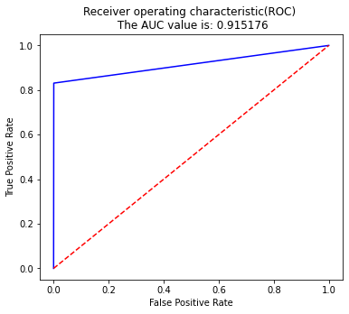

```python
#Using the Best Hyper Parameters derived from the above result
#Setting the best parameters to XGB model

model = XGBClassifier(colsample_bytree = 0.9,
              learning_rate = 0.5,
              max_depth= 7,
              min_child_weight=3,
              n_estimators= 138,
              subsample= 0.8)


model.fit(X_train_adasyn,y_train_adasyn)

#Prediction

y_pred_xg=model.predict(X_test_pt.to_numpy())
#importing the metrics module
from sklearn import metrics
#evaluation(Accuracy)
print("Accuracy:",metrics.accuracy_score(y_pred_xg,y_test))

# create confusion matrix
cm = confusion_matrix(y_test, y_pred_xg)
print(cm)

# Get Common Metrics
sensitivity, specificity, _ = sensitivity_specificity_support(y_test, y_pred_xg, average='binary')
print("Recall/ Sensitivity/ TPR score: \t", round(sensitivity, 4), "\n", "Specificity/Selectivity/TNR score: \t", round(specificity, 4), sep='')
print("Precision/Positive Predictive score: {}".format(precision_score(y_test,y_pred_xg)))
print("F1 Score: {}".format(f1_score(y_test,y_pred_xg)))
print("Overall Accuracy Sore:",metrics.accuracy_score(y_pred_xg,y_test))
print('TRAIN Accuracy: {:2f}'.format(model.score(X_train_adasyn,y_train_adasyn)))
print('TEST Accuracy: {:2f}'.format(model.score(X_test_pt.to_numpy(),y_test)))
print("ROC- AUC Score: ")
xg_roc_auc_curve(y_test,y_pred_xg)
```

## Evaluation Metrics using ADASYN

### Logistic Regression:

1. Overall Accuracy: 0.91112
2. Positive Predictive: 0.017357
3. F1 Score: 0.034088
4. AUC Score: 96951

### Random Forest:

1. Overall Accuracy: **0.99926**
2. Positive Predictive: **0.76510**
3. F1 Score: **0.78350**
4. AUC Score: **0.93298**

### Decision Tree:

1. Overall Accuracy: 0.99742
2. Positive Predictive: 0.36458
3. F1 Score: 0.48837
4. AUC Score: 0.87566

### XG Boost:

1. Overall Accuracy: 0. 999087
2. Positive Predictive: 0. 0.68605
3. F1 Score: 0.75159
4. AUC Score: 0.91517

### Select the oversampling method which shows the best result on a model

- Apply the best hyperparameter on the model
- Predict on the test dataset

## Best models

### Random Oversampling:

#### XG Boost:

1. Overall Accuracy: **0.99954**
2. Positive Predictive: **0.8992**
3. F1 Score: **0.85609**
4. AUC Score: 0.90837

### SMOTE:

#### Random Forest:

1. Overall Accuracy: **0.99925**
2. Positive Predictive: **0.76351**
3. F1 Score: **0.77931**
4. AUC Score: **0.93632**

### ADASYN:

#### Random Forest:

1. Overall Accuracy: **0.99926**
2. Positive Predictive: **0.76510**
3. F1 Score: **0.78350**
4. AUC Score: **0.93298**

```
model = XGBClassifier(colsample_bytree = 0.9,
              learning_rate = 0.5,
              max_depth= 7,
              min_child_weight=3,
              n_estimators= 138,
              subsample= 0.8)
```

```
Accuracy: 0.9995435553526912
[[85288    13]
 [   26   116]]
Recall/ Sensitivity/ TPR score: 	0.8169
Specificity/Selectivity/TNR score: 	0.9998
Precision/Positive Predictive score: 0.8992248062015504
F1 Score: 0.8560885608856088
Overall Accuracy Sore: 0.9995435553526912
TRAIN Accuracy: 1.000000
TEST Accuracy: 0.999087
ROC- AUC Score:
```

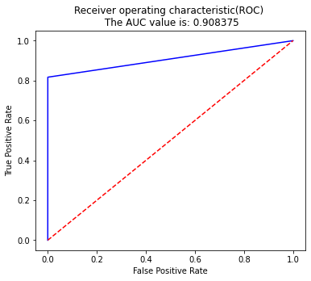

```python
# perform the best oversampling method on X_train & y_train

clf = XGBClassifier(colsample_bytree = 0.9,
              learning_rate = 0.5,
              max_depth= 7,
              min_child_weight=3,
              n_estimators= 138,
              subsample= 0.8)

clf.fit(X_resampled, y_resampled)

#Prediction
y_pred_xg=clf.predict(X_test_pt.to_numpy())
#importing the metrics module
from sklearn import metrics
#evaluation(Accuracy)
print("Accuracy:",metrics.accuracy_score(y_pred_xg,y_test))

# create confusion matrix
cm = confusion_matrix(y_test, y_pred_xg)
print(cm)

# Get Common Metrics
sensitivity, specificity, _ = sensitivity_specificity_support(y_test, y_pred_xg, average='binary')
print("Recall/ Sensitivity/ TPR score: \t", round(sensitivity, 4), "\n", "Specificity/Selectivity/TNR score: \t", round(specificity, 4), sep='')
print("Precision/Positive Predictive score: {}".format(precision_score(y_test,y_pred_xg)))
print("F1 Score: {}".format(f1_score(y_test,y_pred_xg)))
print("Overall Accuracy Sore:",metrics.accuracy_score(y_pred_xg,y_test))
print('TRAIN Accuracy: {:2f}'.format(model.score(X_resampled,y_resampled)))
print('TEST Accuracy: {:2f}'.format(model.score(X_test_pt.to_numpy(),y_test)))
print("ROC- AUC Score: ")
xg_roc_auc_curve(y_test,y_pred_xg)
```

### Print the important features of the best model to understand the dataset

```
Top var = 14
2nd Top var = 10
3rd Top var = 12
```

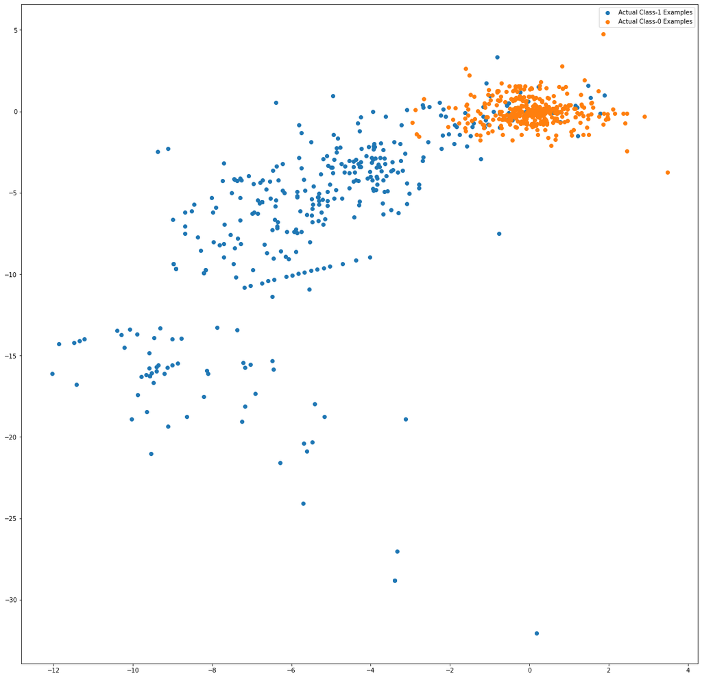

```python
var_imp = []
for i in clf.feature_importances_:
    var_imp.append(i)
print('Top var =', var_imp.index(np.sort(clf.feature_importances_)[-1])+1)
print('2nd Top var =', var_imp.index(np.sort(clf.feature_importances_)[-2])+1)
print('3rd Top var =', var_imp.index(np.sort(clf.feature_importances_)[-3])+1)

# Variable on Index-14 and Index-9 seems to be the top 2 variables
top_var_index = var_imp.index(np.sort(clf.feature_importances_)[-1])
second_top_var_index = var_imp.index(np.sort(clf.feature_importances_)[-2])

X_train_1 = X_train.to_numpy()[np.where(y_train==1.0)]
X_train_0 = X_train.to_numpy()[np.where(y_train==0.0)]

np.random.shuffle(X_train_0)

import matplotlib.pyplot as plt
%matplotlib inline
plt.rcParams['figure.figsize'] = [20, 20]

plt.scatter(X_train_1[:, top_var_index], X_train_1[:, second_top_var_index], label='Actual Class-1 Examples')
plt.scatter(X_train_0[:X_train_1.shape[0], top_var_index], X_train_0[:X_train_1.shape[0], second_top_var_index],
            label='Actual Class-0 Examples')
plt.legend()
```

```python
#### Print the FPR,TPR & select the best threshold from the roc curve
```

```python
print('Train auc =', metrics.roc_auc_score(y_test,y_pred_xg))
fpr, tpr, thresholds = metrics.roc_curve(y_test,y_pred_xg)
# print('FPR =', fpr)
# print('TPR =', tpr)
threshold = thresholds[np.argmax(tpr-fpr)]
print(threshold)
```

```
Train auc = 0.9083745034774126
1
```

```python
from datetime import datetime

now = datetime.now()

current_time = now.strftime("%H:%M:%S")
print("End Time =", current_time)
```

```
End Time = 12:50:01
```